# ¿Qué tan mortal es un siniestro vial en cada localidad de Bogotá?

Probabilidad e Inferencia · Modelos bayesianos Beta–Binomial y Gamma–Poisson con pruebas de bondad de ajuste

Maria Paula Bonilla Martinez · Juan Sebastián Guayazán Clavijo

2026-10-21

# 1 Objetivos e hipótesis

## 1.1 Objetivo general

**Estimar**, con modelos bayesianos Beta–Binomial y Gamma–Poisson, la probabilidad de que un siniestro vial deje al menos un muerto en cada localidad de Bogotá D.C. entre 2018 y 2020, y **comparar** la letalidad de Usme, la localidad con mayor probabilidad observada, con la del resto de la ciudad en periodo normal y durante la cuarentena de 2020.

## 1.2 Objetivos específicos

1. **Estimar** la probabilidad $p$ de siniestro con muertos en cada localidad, con su intervalo de credibilidad, a partir de una prior construida con la historia de la ciudad (2015–2017).
2. **Comparar** la letalidad de cada localidad con la del resto de Bogotá mediante contrastes bayesianos, e identificar cuáles quedan por encima, por debajo o compatibles con la ciudad.
3. **Analizar** si los siniestros con muertos siguen una distribución Binomial (y los conteos diarios una Poisson) mediante pruebas de bondad de ajuste, y qué implica el resultado para el diseño del modelo.
4. **Comparar** la letalidad de la cuarentena de 2020 con la del periodo normal, y **evaluar** si un modelo ajustado con 2018–2019 predice cada periodo.
5. **Analizar** qué tanto dependen las conclusiones de la prior elegida (histórica, Jeffreys, uniforme y escéptica).
6. **Estimar**, con funciones de pérdida explícitas, qué localidades conviene intervenir primero y qué tan robusta es esa decisión.
7. **Contrastar** los resultados analíticos con simulación MCMC en JAGS y **extenderlos** a un modelo jerárquico que corrija haber elegido la localidad más extrema.

## 1.3 Hipótesis del proyecto

Cada hipótesis dice **qué se espera y con qué magnitud**; no es una prueba de hipótesis. Se contrastan con los resultados en la sección “Contraste de las hipótesis”.

|  | Hipótesis | Magnitud esperada |
| --- | --- | --- |
| **H1** | La probabilidad de siniestro con muertos en **Usme** supera a la del resto de la ciudad. | Al menos **1 punto porcentual** más, con probabilidad posterior mayor a 0,95. |
| **H2** | En la **cuarentena** de 2020 los siniestros fueron más mortales que en periodo normal. | Razón de probabilidades de al menos **1,25**, con probabilidad posterior mayor a 0,95. |
| **H3** | La conclusión sobre Usme **no depende de la prior** elegida. | $P(p>p_0\mid\text{datos}) > 0{,}99$ con las cuatro priors. |
| **H4** | Un modelo ajustado con 2018–2019 **predice** los siniestros con muertos de 2020 sin cuarentena. | El valor observado cae dentro del intervalo predictivo del 95 % en Bogotá, Usme y Kennedy. |

# 2 Notación y términos

Para que conteos, proporciones y parámetros no se mezclen en el informe:

| Símbolo | Qué es | Cómo se llama aquí |
| --- | --- | --- |
| $y,\ n$ | siniestros **con muertos** y siniestros totales de una localidad y periodo | conteos |
| $p$ | probabilidad de que **un siniestro deje al menos un muerto** | *probabilidad* (o proporción) de siniestro con muertos; **no** es una tasa por habitante |
| $p_0$ | proporción observada en Bogotá en el periodo reciente (2018–2020 sin cuarentena), 1,40 % | referencia de la ciudad |
| $\lambda$ | siniestros con muertos **por día** | *tasa* diaria |
| $a, b$ | parámetros de la Beta ($a+b$ = siniestros “imaginarios”) | prior / posterior |

El dataset cuenta dos unidades distintas: **2.995 siniestros con muertos** y **3.074 personas fallecidas** (un siniestro puede dejar más de un muerto). Todo el modelo usa la primera.

# 3 Librerías

```r
library(readxl)
library(dplyr)
library(ggplot2)
library(rjags)      # interfaz a JAGS (hay que instalar JAGS: https://mcmc-jags.sourceforge.io)
library(coda)       # diagnósticos de convergencia
```

# 4 Importar los datos

El archivo de la Secretaría Distrital de Movilidad trae cinco hojas. Se usan dos: `SINIESTROS` (una fila por siniestro) y `ACTOR_VIAL` (una fila por persona involucrada). Leer el xlsx tarda alrededor de un minuto porque pesa casi 50 MB.

```r
archivo <- "siniestros_viales_consolidados_bogota_dc.xlsx"
ruta <- if (file.exists(file.path("data", "raw", archivo))) file.path("data", "raw", archivo) else archivo   # en el repo o junto al Rmd
sin   <- read_excel(ruta, sheet = "SINIESTROS", guess_max = 200000)
actor <- read_excel(ruta, sheet = "ACTOR_VIAL", guess_max = 200000)
dim(sin); names(sin)
```

```
## [1] 196152     10
```

```
##  [1] "CODIGO_ACCIDENTE" "FECHA"            "HORA"             "GRAVEDAD"
##  [5] "CLASE"            "CHOQUE"           "OBJETO_FIJO"      "DIRECCION"
##  [9] "CODIGO_LOCALIDAD" "DISENO_LUGAR"
```

# 5 Depuración

```r
nombres <- c("Usaquén","Chapinero","Santa Fe","San Cristóbal","Usme","Tunjuelito","Bosa",
             "Kennedy","Fontibón","Engativá","Suba","Barrios Unidos","Teusaquillo","Los Mártires",
             "Antonio Nariño","Puente Aranda","La Candelaria","Rafael Uribe Uribe",
             "Ciudad Bolívar","Sumapaz")

a_fecha <- function(x) if (inherits(x, c("Date", "POSIXct"))) as.Date(x) else as.Date(x, "%d/%m/%Y")

sin <- sin %>%
  mutate(fecha = a_fecha(FECHA),
         hora  = as.character(HORA),
         anio  = as.integer(format(fecha, "%Y")),
         fila  = row_number(),
         y     = as.integer(GRAVEDAD == 1),                       # 1 = siniestro con muertos
         localidad  = nombres[CODIGO_LOCALIDAD],
         cuarentena = fecha >= as.Date("2020-03-25") & fecha <= as.Date("2020-08-31")) %>%
  arrange(fecha, hora, fila)                                      # orden cronologico

# faltantes y duplicados en las variables que se usan
c(faltantes  = sum(is.na(sin$GRAVEDAD) | is.na(sin$fecha) | is.na(sin$CODIGO_LOCALIDAD)),
  duplicados = sum(duplicated(sin$CODIGO_ACCIDENTE)))
```

```
##  faltantes duplicados
##          0          0
```

```r
table(sin$GRAVEDAD)   # 1 = con muertos, 2 = con heridos, 3 = solo daños
```

```
##
##      1      2      3
##   2995  65238 127919
```

```r
hist <- sin %>% filter(anio <= 2017)                  # historico -> prior
rec  <- sin %>% filter(anio >= 2018, !cuarentena)     # reciente  -> verosimilitud
cua  <- sin %>% filter(cuarentena)                    # cuarentena 2020
p0   <- mean(rec$y)                                   # tasa de Bogota, periodo reciente
c(historico = nrow(hist), reciente = nrow(rec), cuarentena = nrow(cua), p0 = p0)
```

```
##    historico     reciente   cuarentena           p0
## 1,015000e+05 8,792900e+04 6,723000e+03 1,403405e-02
```

No hay faltantes ni duplicados. Hay 196.152 siniestros: 101.500 históricos (2015–2017), 87.929 recientes (2018–2020 sin cuarentena) y 6.723 de la cuarentena. La tasa de Bogotá en el periodo reciente es p₀ = 1.234 / 87.929 = 1,40 %.

# 6 Análisis exploratorio

```r
round(100 * prop.table(table(sin$GRAVEDAD)), 2)
```

```
##
##     1     2     3
##  1,53 33,26 65,21
```

```r
# tasa por anio con IC exacto
ta <- sin %>% group_by(anio) %>%
  summarise(n = n(), y = sum(y), p = y / n,
            li = qbeta(0.025, y, n - y + 1), ls = qbeta(0.975, y + 1, n - y), .groups = "drop")
ta
```

```
## # A tibble: 6 × 6
##    anio     n     y      p     li     ls
##   <int> <int> <int>  <dbl>  <dbl>  <dbl>
## 1  2015 31341   529 0.0169 0.0155 0.0184
## 2  2016 34988   567 0.0162 0.0149 0.0176
## 3  2017 35171   538 0.0153 0.0140 0.0166
## 4  2018 36953   500 0.0135 0.0124 0.0148
## 5  2019 34990   492 0.0141 0.0129 0.0154
## 6  2020 22709   369 0.0162 0.0146 0.0180
```

```r
c(cuarentena = mean(cua$y))
```

```
## cuarentena
## 0,01889038
```

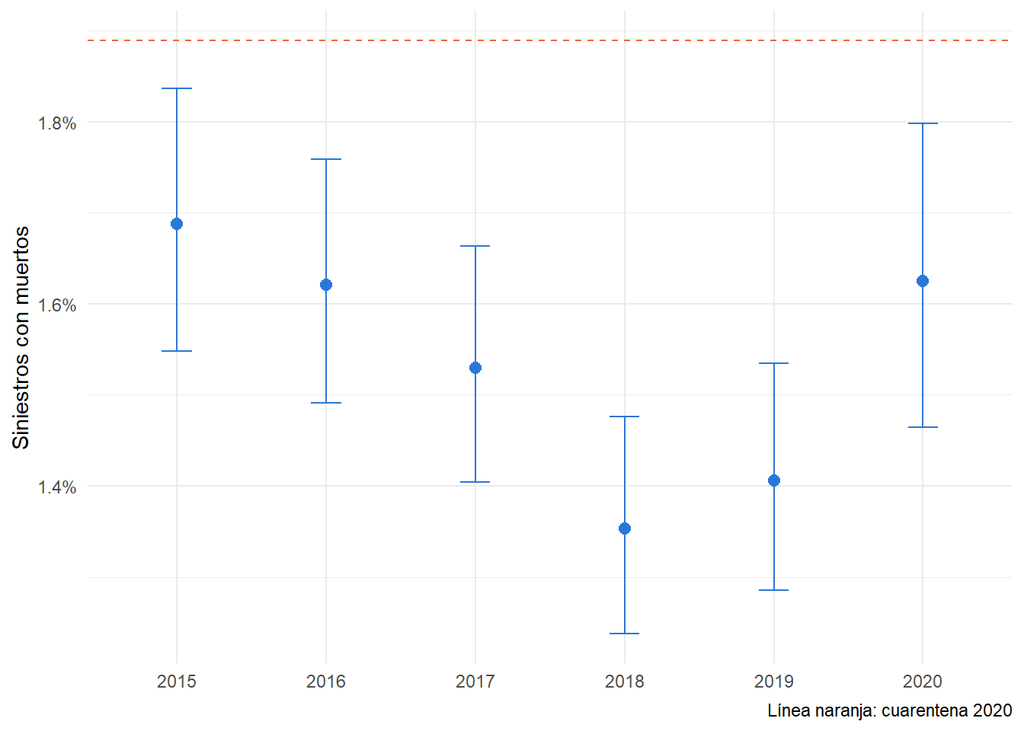

```r
ggplot(ta, aes(factor(anio), p)) +
  geom_errorbar(aes(ymin = li, ymax = ls), width = 0.2, color = "#2a78d6") +
  geom_point(size = 2.5, color = "#2a78d6") +
  geom_hline(yintercept = mean(cua$y), linetype = "dashed", color = "#eb6834") +
  scale_y_continuous(labels = scales::percent) +
  labs(x = NULL, y = "Siniestros con muertos", caption = "Línea naranja: cuarentena 2020") +
  theme_minimal()
```

El 1,5 % de los siniestros deja muertos, el 33,3 % heridos y el 65,2 % solo daños. La tasa bajó de 1,69 % (2015) a 1,35 % (2018) y en la cuarentena subió a 1,89 %.

```r
# serie mensual 2019-2020: menos siniestros, pero mas mortales
mes <- sin %>% filter(fecha >= as.Date("2019-01-01")) %>%
  mutate(mes = format(fecha, "%Y-%m")) %>%
  group_by(mes) %>% summarise(n = n(), y = sum(y), p = y / n, .groups = "drop")
mes %>% filter(mes >= "2020-01")
```

```
## # A tibble: 12 × 4
##    mes         n     y      p
##    <chr>   <int> <int>  <dbl>
##  1 2020-01  2304    28 0.0122
##  2 2020-02  2827    38 0.0134
##  3 2020-03  1891    25 0.0132
##  4 2020-04   687    21 0.0306
##  5 2020-05  1150    21 0.0183
##  6 2020-06  1518    24 0.0158
##  7 2020-07  1626    23 0.0141
##  8 2020-08  1648    37 0.0225
##  9 2020-09  2051    40 0.0195
## 10 2020-10  2294    40 0.0174
## 11 2020-11  2317    37 0.0160
## 12 2020-12  2396    35 0.0146
```

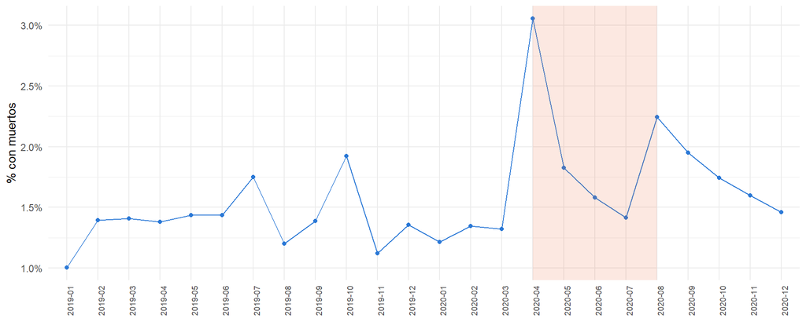

```r
ggplot(mes, aes(mes, p, group = 1)) + geom_line(color = "#2a78d6") + geom_point(color = "#2a78d6") +
  annotate("rect", xmin = "2020-04", xmax = "2020-08", ymin = -Inf, ymax = Inf, alpha = 0.15, fill = "#eb6834") +
  scale_y_continuous(labels = scales::percent) + labs(x = NULL, y = "% con muertos") +
  theme_minimal() + theme(axis.text.x = element_text(angle = 90, size = 7))
```

En abril de 2020 hubo 687 siniestros (frente a unos 2.800 al mes en 2019) y el 3,1 % dejó muertos: el doble de lo normal.

```r
# quien muere: condicion del actor vial fallecido
actor %>% filter(ESTADO == "MUERTO") %>% count(CONDICION, sort = TRUE) %>%
  mutate(pct = round(100 * n / sum(n), 1))
```

```
## # A tibble: 5 × 3
##   CONDICION                n   pct
##   <chr>                <int> <dbl>
## 1 PEATON                1433  46.6
## 2 MOTOCICLISTA           877  28.5
## 3 CICLISTA               394  12.8
## 4 PASAJERO/ACOMPAÑANTE   308  10
## 5 CONDUCTOR               62   2
```

```r
# que tan mortal es cada clase de siniestro
clases <- c("Choque","Atropello","Volcamiento","Caida de ocupante","Incendio","Otro","Autolesion")
sin %>% group_by(clase = clases[CLASE]) %>% summarise(n = n(), y = sum(y), p = round(100 * y / n, 2)) %>%
  arrange(desc(p))
```

```
## # A tibble: 7 × 4
##   clase                  n     y     p
##   <chr>              <int> <int> <dbl>
## 1 Volcamiento         2615   251  9.6
## 2 Atropello          20101  1381  6.87
## 3 Otro                 788     9  1.14
## 4 Caida de ocupante   4694    40  0.85
## 5 Choque            167915  1314  0.78
## 6 Autolesion            14     0  0
## 7 Incendio              25     0  0
```

```r
# tasa por localidad en el periodo reciente
rec %>% group_by(localidad) %>% summarise(n = n(), y = sum(y), p = round(100 * y / n, 2)) %>%
  arrange(desc(p))
```

```
## # A tibble: 20 × 4
##    localidad              n     y     p
##    <chr>              <int> <int> <dbl>
##  1 Sumapaz                6     3 50
##  2 Usme                1811    62  3.42
##  3 Ciudad Bolívar      3581    96  2.68
##  4 Rafael Uribe Uribe  2230    54  2.42
##  5 Tunjuelito          2550    48  1.88
##  6 Bosa                4781    82  1.72
##  7 San Cristóbal       2697    45  1.67
##  8 Antonio Nariño      1802    29  1.61
##  9 Puente Aranda       6291    95  1.51
## 10 Kennedy             9793   147  1.5
## 11 Santa Fe            2675    39  1.46
## 12 Fontibón            7241   102  1.41
## 13 Engativá            8761   115  1.31
## 14 Los Mártires        2929    38  1.3
## 15 La Candelaria        407     5  1.23
## 16 Suba                7542    92  1.22
## 17 Teusaquillo         4540    41  0.9
## 18 Barrios Unidos      4618    36  0.78
## 19 Chapinero           4947    38  0.77
## 20 Usaquén             8727    67  0.77
```

El 46,6 % de los fallecidos son peatones y el 28,5 % motociclistas. Un atropello deja muertos el 6,9 % de las veces y un choque el 0,8 %. Por localidad la tasa va de 0,77 % (Usaquén, Chapinero) a 3,42 % (Usme); Kennedy acumula más siniestros con muertos que cualquier otra, pero con una tasa (1,50 %) parecida a la de la ciudad.

# 7 ¿Es binomial? Pruebas de supuestos

Para que Y, el número de siniestros con muertos entre n siniestros, sea binomial se necesitan cuatro cosas: dos resultados, n fijo, independencia y probabilidad constante. Las dos primeras se cumplen por construcción. Las otras se prueban en el periodo reciente para **Bogotá**, para **Usme** (localidad principal) y para **Kennedy** (comparación).

```r
bog <- rec
usm <- rec %>% filter(CODIGO_LOCALIDAD == 5)
ken <- rec %>% filter(CODIGO_LOCALIDAD == 8)
```

## 7.1 Supuesto 1 · Independencia: prueba de rachas

```r
rachas <- function(x) {
  n1 <- sum(x == 1); n0 <- sum(x == 0); n <- n1 + n0
  R  <- 1 + sum(x[-1] != x[-n])                          # rachas observadas
  mu <- 2 * n1 * n0 / n + 1                               # esperadas si hay independencia
  v  <- 2 * n1 * n0 * (2 * n1 * n0 - n) / (n^2 * (n - 1))
  z  <- (R - mu) / sqrt(v)
  c(rachas = R, esperadas = mu, z = z, p_valor = 2 * pnorm(-abs(z)))
}
rbind(Bogota = rachas(bog$y), Usme = rachas(usm$y), Kennedy = rachas(ken$y))
```

```
##         rachas esperadas          z   p_valor
## Bogota    2425 2434,3640 -1,1413150 0,2537389
## Usme       119  120,7548 -0,6260407 0,5312883
## Kennedy    291  290,5868  0,1414224 0,8875363
```

Bogotá: 2.425 rachas contra 2.434 esperadas, `p = 0,25`. Usme `p = 0,53`, Kennedy `p = 0,89`. **No hay evidencia de que la gravedad de un siniestro influya en la del siguiente.**

## 7.2 Supuesto 2 · Probabilidad constante: homogeneidad

```r
homog <- function(dd, g) {
  t <- dd %>% group_by(.data[[g]]) %>% summarise(y = sum(y), n = n(), .groups = "drop")
  chisq.test(cbind(t$y, t$n - t$y), correct = FALSE)
}
homog(bog, "anio"); homog(usm, "anio"); homog(ken, "anio")      # 2018-2020: se cumple
```

```
##
##  Pearson's Chi-squared test
##
## data:  cbind(t$y, t$n - t$y)
## X-squared = 2,0871, df = 2, p-value = 0,3522
```

```
##
##  Pearson's Chi-squared test
##
## data:  cbind(t$y, t$n - t$y)
## X-squared = 0,60646, df = 2, p-value = 0,7384
```

```
##
##  Pearson's Chi-squared test
##
## data:  cbind(t$y, t$n - t$y)
## X-squared = 2,5311, df = 2, p-value = 0,2821
```

```r
homog(sin %>% filter(!cuarentena), "anio")                       # 2015-2020: NO se cumple
```

```
##
##  Pearson's Chi-squared test
##
## data:  cbind(t$y, t$n - t$y)
## X-squared = 18,227, df = 5, p-value = 0,002675
```

```r
homog(bind_rows(rec %>% mutate(g = "normal"), cua %>% mutate(g = "cuarentena")), "g")
```

```
##
##  Pearson's Chi-squared test
##
## data:  cbind(t$y, t$n - t$y)
## X-squared = 10,393, df = 1, p-value = 0,001265
```

```r
homog(rec %>% filter(CODIGO_LOCALIDAD != 20), "localidad")       # entre localidades: NO
```

```
##
##  Pearson's Chi-squared test
##
## data:  cbind(t$y, t$n - t$y)
## X-squared = 187,33, df = 18, p-value < 2,2e-16
```

Entre 2018 y 2020 la probabilidad es constante en Bogotá (`p = 0,35`), Usme (`p = 0,74`) y Kennedy (`p = 0,28`). Con los seis años juntos se rechaza (`chi2 = 18,2`, `gl = 5`, `p = 0,003`): por eso el histórico va en la prior. También se rechaza que la cuarentena tenga la misma p que el periodo normal (`p = 0,001`) y que las 19 localidades compartan la misma p (`chi2 = 187,3`, `gl = 18`, `p < 0,0001`): por eso cada localidad se modela por separado.

## 7.3 Supuesto 3 · Forma binomial: bondad de ajuste en grupos de 50

La p es pequeña (≈ 1,4 %), así que en grupos de 10 casi todo sería cero. Se usan grupos de 50 siniestros consecutivos dentro de cada año: en promedio 0,7 con muertos en Bogotá y 1,8 en Usme.

```r
# conteos de exitos en grupos de m siniestros consecutivos, dentro de cada anio
grupos <- function(dd, m) {
  unlist(lapply(split(dd$y, dd$anio, drop = TRUE), function(v) {
    k <- length(v) %/% m
    if (k == 0) integer(0) else sapply(1:k, function(j) sum(v[((j - 1) * m + 1):(j * m)]))
  }), use.names = FALSE)
}

# chi-cuadrado de bondad de ajuste; agrupa las colas hasta que el esperado sea >= 5
gof <- function(X, m) {
  J <- length(X); ph <- mean(X) / m
  obs <- tabulate(X + 1, nbins = m + 1); esp <- J * dbinom(0:m, m, ph)
  lo <- 1;     while (sum(esp[1:lo]) < 5) lo <- lo + 1
  hi <- m + 1; while (sum(esp[hi:(m + 1)]) < 5) hi <- hi - 1
  mid <- if (lo + 1 <= hi - 1) (lo + 1):(hi - 1) else integer(0)
  O <- c(sum(obs[1:lo]), obs[mid], sum(obs[hi:(m + 1)]))
  E <- c(sum(esp[1:lo]), esp[mid], sum(esp[hi:(m + 1)]))
  chi2 <- sum((O - E)^2 / E); gl <- length(O) - 2         # -1 por p estimada
  c(grupos = J, p_hat = ph, chi2 = chi2, gl = gl,
    p_valor = if (gl > 0) pchisq(chi2, gl, lower.tail = FALSE) else NA)
}

M <- 50
XB <- grupos(bog, M); XU <- grupos(usm, M); XK <- grupos(ken, M)
data.frame(k = 0:6, observado = tabulate(XU + 1, nbins = 7),
           esperado = round(length(XU) * dbinom(0:6, M, mean(XU) / M), 1))   # Usme
```

```
##   k observado esperado
## 1 0         4      5,8
## 2 1        12     10,6
## 3 2         9      9,5
## 4 3         8      5,6
## 5 4         2      2,4
## 6 5         0      0,8
## 7 6         0      0,2
```

```r
rbind(Bogota = gof(XB, M), Usme = gof(XU, M), Kennedy = gof(XK, M))
```

```
##         grupos      p_hat     chi2 gl   p_valor
## Bogota    1757 0,01404667 2,692087  3 0,4415737
## Usme        35 0,03542857 0,842740  2 0,6561473
## Kennedy    195 0,01497436 1,729414  2 0,4211750
```

Bogotá `chi2 = 2,69`, `gl = 3`, `p = 0,44`; Usme `p = 0,66`; Kennedy `p = 0,42`. **Observado y esperado coinciden.**

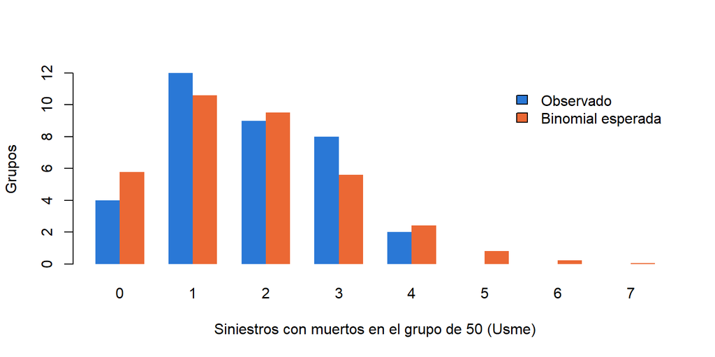

```r
barplot(rbind(tabulate(XU + 1, nbins = 8), length(XU) * dbinom(0:7, M, mean(XU) / M)),
        beside = TRUE, names.arg = 0:7, col = c("#2a78d6", "#eb6834"), border = NA,
        legend.text = c("Observado", "Binomial esperada"), args.legend = list(bty = "n"),
        xlab = "Siniestros con muertos en el grupo de 50 (Usme)", ylab = "Grupos")
```

## 7.4 Supuesto 4 · Sin sobredispersión

```r
dispersion <- function(X, m) {
  J <- length(X); ph <- mean(X) / m; vb <- m * ph * (1 - ph)
  D <- (J - 1) * var(X) / vb                                 # ~ chi2(J - 1) si es binomial
  c(var_observada = var(X), var_binomial = vb, razon = var(X) / vb,
    p_valor = 2 * min(pchisq(D, J - 1), pchisq(D, J - 1, lower.tail = FALSE)))
}
rbind(Bogota = dispersion(XB, M), Usme = dispersion(XU, M), Kennedy = dispersion(XK, M))
```

```
##         var_observada var_binomial     razon   p_valor
## Bogota      0,7274034    0,6924681 1,0504505 0,1384253
## Usme        1,2403361    1,7086694 0,7259076 0,2416421
## Kennedy     0,8489030    0,7375064 1,1510449 0,1464614
```

Razones de 1,05 (Bogotá), 0,73 (Usme) y 1,15 (Kennedy), ninguna significativa (`p` = 0,14; 0,24; 0,15). Kennedy muestra una leve sobredispersión que hay que mencionar.

## 7.5 Robustez al tamaño del grupo

```r
rob <- function(dd) t(sapply(c(25, 50, 100), function(m) {
  X <- grupos(dd, m); c(m = m, gof(X, m)[c("grupos", "chi2", "gl", "p_valor")], dispersion(X, m)[c("razon", "p_valor")])
}))
rob(bog); rob(usm); rob(ken)
```

```
##        m grupos     chi2 gl   p_valor    razon    p_valor
## [1,]  25   3516 1,702866  2 0,4268028 1,043226 0,07272138
## [2,]  50   1757 2,692087  3 0,4415737 1,050450 0,13842532
## [3,] 100    877 2,458711  4 0,6520441 1,037232 0,43208513
```

```
##        m grupos      chi2 gl   p_valor     razon   p_valor
## [1,]  25     71 0,3441222  1 0,5574594 0,7773841 0,1699703
## [2,]  50     35 0,8427400  2 0,6561473 0,7259076 0,2416421
## [3,] 100     16 0,2997977  0        NA 0,5150372 0,1313731
```

```
##        m grupos     chi2 gl    p_valor    razon    p_valor
## [1,]  25    391 5,545624  1 0,01852695 1,181468 0,01557452
## [2,]  50    195 1,729414  2 0,42117501 1,151045 0,14646137
## [3,] 100     97 4,836709  3 0,18415209 1,091168 0,50850019
```

Con grupos de 25, 50 y 100 el ajuste se mantiene en Bogotá y Usme. En Kennedy con grupos de 25 la prueba rechaza (`p = 0,02`, razón 1,18): siniestros graves algo agrupados en el tiempo. Con 50 y 100 no.

# 8 La prior: lo que enseña la historia de la ciudad

La prior se construye con 2015–2017, antes de los datos que se van a analizar. No se toma la tasa de la ciudad con el peso de 101.500 siniestros (eso aplastaría a cualquier localidad), sino cuánto varían las localidades entre sí: una Beta con la media y la varianza de las 19 tasas históricas (método de los momentos), descontando la parte de la varianza que es solo azar binomial.

```r
th <- hist %>% filter(CODIGO_LOCALIDAD != 20) %>%
  group_by(CODIGO_LOCALIDAD) %>% summarise(n = n(), y = sum(y), p = y / n, .groups = "drop")
m_h    <- sum(th$y) / sum(th$n)                         # media historica (1,61 %)
v_obs  <- sum((th$p - m_h)^2) / (nrow(th) - 1)          # varianza entre localidades
v_bin  <- mean(m_h * (1 - m_h) / th$n)                  # parte que es solo azar
peso   <- m_h * (1 - m_h) / (v_obs - v_bin) - 1         # siniestros imaginarios
aH <- m_h * peso; bH <- (1 - m_h) * peso
c(media = m_h, peso = peso, a = aH, b = bH, li = qbeta(0.025, aH, bH), ls = qbeta(0.975, aH, bH))
```

```
##        media         peso            a            b           li           ls
## 1,609868e-02 2,858950e+02 4,602533e+00 2,812925e+02 4,951665e-03 3,355573e-02
```

La prior es Beta(4,60; 281,29): media 1,61 %, pesa como 286 siniestros y dice que la tasa de una localidad cualquiera está, con 95 % de probabilidad, entre 0,50 % y 3,36 %.

**Fuente de la información previa.** La prior sale de los siniestros viales registrados por la Secretaría Distrital de Movilidad entre el 1 de enero de 2015 y el 31 de diciembre de 2017: **101.500 siniestros, 1.634 con al menos un muerto** (1,61 %), en 19 localidades (sin Sumapaz) (Secretaría Distrital de Movilidad, 2021). Se construye con el método de los momentos sobre las tasas de las 19 localidades, descontando la varianza que es solo azar binomial, siguiendo la idea de los modelos jerárquicos con Beta–Binomial (Gelman et al., 2013, cap. 5). Esos datos **no se reutilizan** en la verosimilitud (2018–2020), de modo que la información previa y los datos son independientes.

# 9 MODELO · Beta–Binomial por localidad

`p | datos ~ Beta(a + y, b + n − y)`

```r
resumen <- function(a, b) c(a = a, b = b, media = a / (a + b),
  li = qbeta(0.025, a, b), ls = qbeta(0.975, a, b), p_mayor_p0 = 1 - pbeta(p0, a, b))

# factor de Bayes de H0: p = p0 frente a H1: p ~ Beta(a, b)
bf01 <- function(y, n, a, b) exp(y * log(p0) + (n - y) * log(1 - p0) -
                                 (lbeta(a + y, b + n - y) - lbeta(a, b)))

yU <- sum(usm$y); nU <- nrow(usm); yK <- sum(ken$y); nK <- nrow(ken)
rbind(Usme_prior   = resumen(aH, bH),
      Usme_post    = resumen(aH + yU, bH + nU - yU),
      Kennedy_post = resumen(aH + yK, bH + nK - yK))
```

```
##                       a         b      media          li         ls p_mayor_p0
## Usme_prior     4,602533  281,2925 0,01609868 0,004951665 0,03355573  0,5540109
## Usme_post     66,602533 2030,2925 0,03176245 0,024690527 0,03967957  1,0000000
## Kennedy_post 151,602533 9927,2925 0,01504158 0,012757889 0,01750749  0,7948623
```

```r
c(BF01_Usme = bf01(yU, nU, aH, bH), BF01_Kennedy = bf01(yK, nK, aH, bH))
```

```
##    BF01_Usme BF01_Kennedy
## 9,441678e-08 4,246797e+00
```

**Usme:** posterior Beta(66,6; 2.030,3), media 3,18 %, intervalo del 95 % [2,47 %; 3,97 %]. El intervalo no contiene a p₀ = 1,40 %, P(p > p₀ | datos) ≈ 1 y el factor de Bayes BF₀₁ = 9 × 10⁻⁸: los datos son unas diez millones de veces más compatibles con H₁. Se rechaza H₀: en Usme un siniestro es más del doble de mortal que en Bogotá.**

**Kennedy:** media 1,50 %, intervalo [1,28 %; 1,75 %], que sí contiene a p₀. BF₀₁ = 4,2 a favor de H₀: Kennedy tiene muchos muertos porque tiene muchos siniestros, no porque sean más mortales.

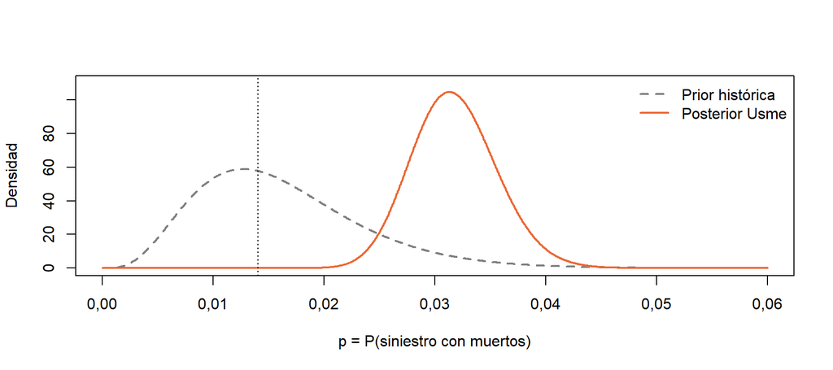

```r
curve(dbeta(x, aH, bH), from = 0, to = 0.06, n = 1000, lwd = 2, lty = 2, col = "gray50",
      ylim = c(0, 110), xlab = "p = P(siniestro con muertos)", ylab = "Densidad")
curve(dbeta(x, aH + yU, bH + nU - yU), add = TRUE, n = 1000, lwd = 2, col = "#eb6834")
abline(v = p0, lty = 3)
legend("topright", c("Prior histórica", "Posterior Usme"), col = c("gray50", "#eb6834"),
       lty = c(2, 1), lwd = 2, bty = "n")
```

## 9.1 Cómo leer la prueba de hipótesis bayesiana

Con una prior continua, $P(p = p_0 \mid \text{datos}) = 0$ siempre: la hipótesis puntual $H_0: p = p_0$ no se puede “probar” mirando solo la posterior. Por eso se reportan **tres criterios juntos**, cada uno responde algo distinto:

| Criterio | Qué responde | Cómo se calcula |
| --- | --- | --- |
| $P(p > p_0 \mid \text{datos})$ | ¿Qué tan probable es que la localidad sea *más* mortal que Bogotá? | `1 - pbeta(p0, a, b)` |
| ROPE (región de equivalencia práctica) | ¿Cuánta de la posterior cae en “diferencia práctica nula” alrededor de $p_0$? | masa en $p_0 \pm 0{,}25$ pp |
| Factor de Bayes $BF_{01}$ | ¿Qué tan probables son los datos si $p = p_0$ frente a si $p \sim$ Beta$(a,b)$? | cociente de marginales |

El ancho del ROPE (±0,25 pp) es un **supuesto de quien analiza**: cambia $P(\text{ROPE})$, no $P(p>p_0\mid\text{datos})$.

```r
ROPE <- 0.0025
rope_p <- function(a, b) pbeta(p0 + ROPE, a, b) - pbeta(p0 - ROPE, a, b)
data.frame(localidad = c("Usme", "Kennedy"),
           media = c((aH + yU) / (aH + bH + nU), (aH + yK) / (aH + bH + nK)),
           P_mayor_p0 = c(1 - pbeta(p0, aH + yU, bH + nU - yU), 1 - pbeta(p0, aH + yK, bH + nK - yK)),
           P_ROPE = c(rope_p(aH + yU, bH + nU - yU), rope_p(aH + yK, bH + nK - yK)),
           BF01 = c(bf01(yU, nU, aH, bH), bf01(yK, nK, aH, bH)))
```

```
##   localidad      media P_mayor_p0       P_ROPE         BF01
## 1      Usme 0,03176245  1,0000000 7,306664e-07 9,441678e-08
## 2   Kennedy 0,01504158  0,7948623 8,877427e-01 4,246797e+00
```

En Usme, la posterior queda **fuera** del ROPE (masa casi nula) y $P(p>p_0)\approx 1$. En Kennedy, casi toda la posterior cae dentro del ROPE: es **práctica y estadísticamente compatible** con la ciudad.

### 9.1.1 Una advertencia sobre el factor de Bayes (paradoja de Lindley–Jeffreys)

El $BF_{01}$ depende mucho de la prior de $H_1$. Si $H_1$ reparte su probabilidad en un rango muy amplio (una prior difusa), asigna poca densidad a los valores cercanos a $p_0$ y **se “castiga” por ser vaga**: el $BF_{01}$ favorece a $H_0$ aunque la diferencia sea real. Para verlo, se barre el **peso** $m = a + b$ de una prior con la misma media histórica (1,61 %):

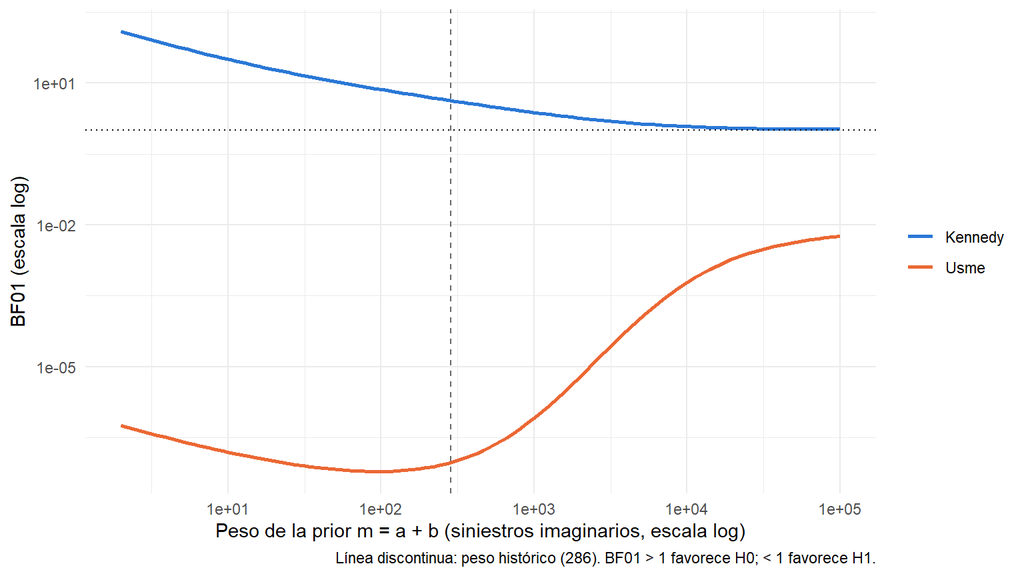

```r
ms <- 10^seq(log10(2), 5, length.out = 100)
barr <- do.call(rbind, lapply(c(Usme = "Usme", Kennedy = "Kennedy"), function(nm) {
  y_ <- if (nm == "Usme") yU else yK; n_ <- if (nm == "Usme") nU else nK
  data.frame(localidad = nm, m = ms,
             BF01 = sapply(ms, function(m) bf01(y_, n_, m_h * m, (1 - m_h) * m)),
             P_mayor = sapply(ms, function(m) 1 - pbeta(p0, m_h * m + y_, (1 - m_h) * m + n_ - y_)))
}))
ggplot(barr, aes(m, BF01, colour = localidad)) + geom_line(linewidth = 0.9) +
  geom_hline(yintercept = 1, linetype = "dotted") + geom_vline(xintercept = peso, linetype = "dashed", colour = "gray40") +
  scale_x_log10() + scale_y_log10() + scale_colour_manual(values = c(Usme = "#eb6834", Kennedy = "#2a78d6"), name = NULL) +
  labs(x = "Peso de la prior m = a + b (siniestros imaginarios, escala log)", y = "BF01 (escala log)",
       caption = "Línea discontinua: peso histórico (286). BF01 > 1 favorece H0; < 1 favorece H1.") +
  theme_minimal()
```

```r
barr %>% filter(m %in% ms[c(1, 25, 50, 75, 100)]) %>% mutate(across(c(BF01, P_mayor), ~ signif(.x, 3)))
```

```
##             localidad            m     BF01 P_mayor
## Usme.1           Usme      2,00000 5,72e-07   1,000
## Usme.25          Usme     27,55334 8,49e-08   1,000
## Usme.50          Usme    423,43117 1,48e-07   1,000
## Usme.75          Usme   6507,15892 2,22e-04   1,000
## Usme.100         Usme 100000,00000 5,76e-03   1,000
## Kennedy.1     Kennedy      2,00000 1,22e+02   0,784
## Kennedy.25    Kennedy     27,55334 1,56e+01   0,785
## Kennedy.50    Kennedy    423,43117 3,51e+00   0,800
## Kennedy.75    Kennedy   6507,15892 1,30e+00   0,931
## Kennedy.100   Kennedy 100000,00000 1,06e+00   1,000
```

**Lectura.** En **Usme**, el $BF_{01}$ está por debajo de 1 con *cualquier* peso de prior: la conclusión no depende de la prior elegida. En **Kennedy**, el $BF_{01}$ sube cuanto más difusa es la prior: con la histórica vale 4,2, pero con una prior casi uniforme (peso 2) vale 120. Ese “apoyo fuerte a $H_0$” es en buena parte un artefacto de la vaguedad de la prior, no evidencia fuerte de igualdad. Por eso conviene apoyarse además en el intervalo de credibilidad y el ROPE, que no sufren este problema: ambos dicen lo mismo para Kennedy (compatible con la ciudad) sin depender del peso de la prior.

## 9.2 Las 19 localidades

```r
tab <- rec %>% group_by(CODIGO_LOCALIDAD, localidad) %>% summarise(n = n(), y = sum(y), .groups = "drop") %>%
  rowwise() %>%
  mutate(a = aH + y, b = bH + n - y, media = a / (a + b),
         li = qbeta(0.025, a, b), ls = qbeta(0.975, a, b),
         p_mayor_p0 = 1 - pbeta(p0, a, b), BF01 = bf01(y, n, aH, bH),
         P_H0 = BF01 / (1 + BF01)) %>% ungroup() %>% arrange(desc(media))
tab %>% mutate(across(c(media, li, ls), ~ round(100 * .x, 2)), across(c(p_mayor_p0, BF01, P_H0), ~ signif(.x, 3)))
```

```
## # A tibble: 20 × 12
##    CODIGO_LOCALIDAD localidad             n     y      a     b media    li    ls
##               <dbl> <chr>             <int> <int>  <dbl> <dbl> <dbl> <dbl> <dbl>
##  1                5 Usme               1811    62  66.6  2030.  3.18  2.47  3.97
##  2               20 Sumapaz               6     3   7.60  284.  2.6   1.11  4.71
##  3               19 Ciudad Bolívar     3581    96 101.   3766.  2.6   2.12  3.13
##  4               18 Rafael Uribe Uri…  2230    54  58.6  2457.  2.33  1.78  2.95
##  5                6 Tunjuelito         2550    48  52.6  2783.  1.85  1.39  2.38
##  6                7 Bosa               4781    82  86.6  4980.  1.71  1.37  2.08
##  7                4 San Cristóbal      2697    45  49.6  2933.  1.66  1.24  2.15
##  8               15 Antonio Nariño     1802    29  33.6  2054.  1.61  1.11  2.19
##  9               16 Puente Aranda      6291    95  99.6  6477.  1.51  1.23  1.82
## 10                8 Kennedy            9793   147 152.   9927.  1.5   1.28  1.75
## 11                3 Santa Fe           2675    39  43.6  2917.  1.47  1.07  1.94
## 12                9 Fontibón           7241   102 107.   7420.  1.42  1.16  1.7
## 13               17 La Candelaria       407     5   9.60  683.  1.39  0.66  2.38
## 14               14 Los Mártires       2929    38  42.6  3172.  1.33  0.96  1.75
## 15               10 Engativá           8761   115 120.   8927.  1.32  1.1   1.57
## 16               11 Suba               7542    92  96.6  7731.  1.23  1     1.49
## 17               13 Teusaquillo        4540    41  45.6  4780.  0.94  0.69  1.24
## 18               12 Barrios Unidos     4618    36  40.6  4863.  0.83  0.59  1.1
## 19                2 Chapinero          4947    38  42.6  5190.  0.81  0.59  1.07
## 20                1 Usaquén            8727    67  71.6  8941.  0.79  0.62  0.99
## # ℹ 3 more variables: p_mayor_p0 <dbl>, BF01 <dbl>, P_H0 <dbl>
```

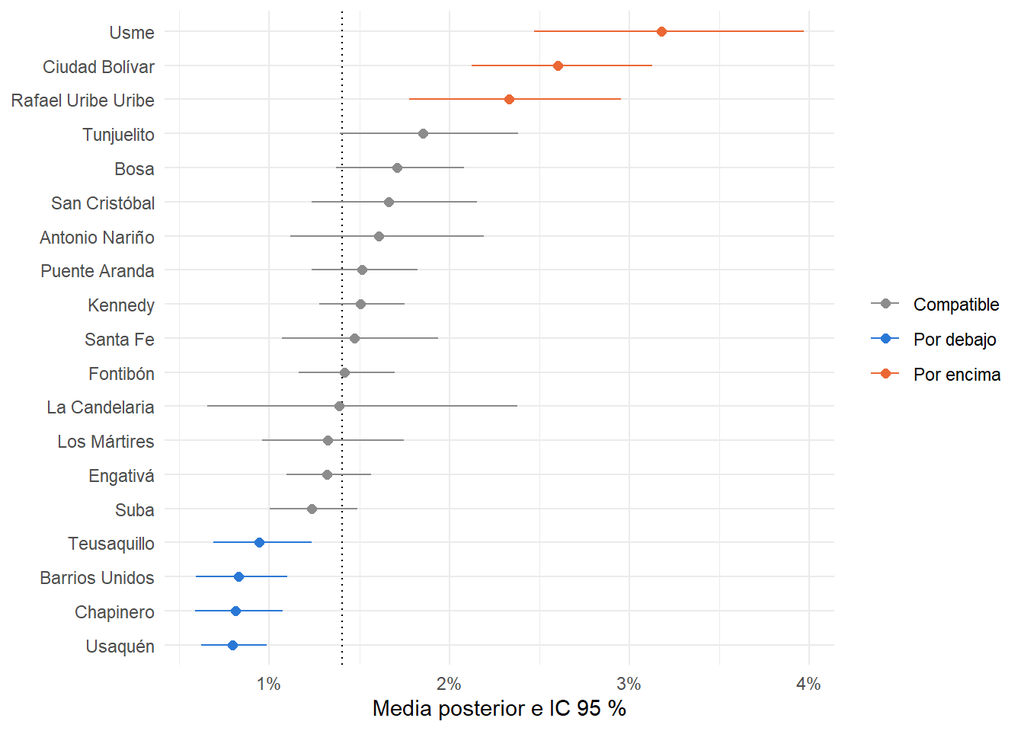

```r
ggplot(tab %>% filter(CODIGO_LOCALIDAD != 20),
       aes(media, reorder(localidad, media),
           color = ifelse(li > p0, "Por encima", ifelse(ls < p0, "Por debajo", "Compatible")))) +
  geom_vline(xintercept = p0, linetype = "dotted") +
  geom_errorbarh(aes(xmin = li, xmax = ls), height = 0) + geom_point(size = 2) +
  scale_color_manual(values = c(`Por encima` = "#eb6834", `Compatible` = "gray55", `Por debajo` = "#2a78d6"), name = NULL) +
  scale_x_continuous(labels = scales::percent) + labs(x = "Media posterior e IC 95 %", y = NULL) + theme_minimal()
```

Por encima de Bogotá: **Usme, Ciudad Bolívar y Rafael Uribe Uribe**. Por debajo: Usaquén, Chapinero, Barrios Unidos y Teusaquillo. Las otras 12 son compatibles con la ciudad.

## 9.3 Usme contra el resto de la ciudad

```r
resto <- rec %>% filter(CODIGO_LOCALIDAD != 5); yR <- sum(resto$y); nR <- nrow(resto)
set.seed(2026)
sU <- rbeta(200000, aH + yU, bH + nU - yU); sR <- rbeta(200000, 1 + yR, 1 + nR - yR)
c(prob_usme_mayor = mean(sU > sR), dif_media = mean(sU - sR), quantile(sU - sR, c(0.025, 0.975)),
  razon_media = mean(sU / sR), quantile(sU / sR, c(0.025, 0.975)))
```

```
## prob_usme_mayor       dif_media            2,5%           97,5%     razon_media
##      1,00000000      0,01815242      0,01101593      0,02610895      2,33476330
##            2,5%           97,5%
##      1,80265826      2,93783949
```

En Usme un siniestro deja muertos 1,8 puntos porcentuales más que en el resto de la ciudad (entre 1,1 y 2,6). Dicho como razón: es 2,3 veces más mortal (entre 1,8 y 2,9).

## 9.4 Todas las localidades contra el resto de la ciudad (contrastes bayesianos completos)

Comparar cada localidad con $p_0$ tratándolo como un número fijo es una simplificación: $p_0$ es también una **estimación** (y además *incluye* a la propia localidad). Un contraste bayesiano completo compara dos **parámetros inciertos**: la probabilidad de la localidad $j$ frente a la del **resto de la ciudad**, $p_{\text{resto},j}$, con la distribución conjunta de ambos (se simulan las dos posteriores, que son independientes porque usan datos distintos):

$$\Delta_j = p_j - p_{\text{resto},j},
\qquad R_j = \frac{p_j}{p_{\text{resto},j}}, \qquad P(p_j >
p_{\text{resto},j}\mid\text{datos}).$$

Para $p_j$ se usa la prior histórica (la principal) y para $p_{\text{resto},j}$ una Beta(1, 1) (el resto tiene decenas de miles de siniestros, la prior no pesa). Se clasifica la localidad como **por encima** si $P(\Delta_j>0)>0{,}975$, **por debajo** si $<0{,}025$ y **compatible** en otro caso (equivale a que el intervalo de credibilidad central del 95 % de $\Delta_j$ excluya el cero).

```r
set.seed(2026)
NS <- 100000
tot_y <- sum(rec$y); tot_n <- nrow(rec)
contr <- do.call(rbind, lapply(seq_len(nrow(tab)), function(i) {
  yj <- tab$y[i]; nj <- tab$n[i]
  sj <- rbeta(NS, aH + yj, bH + nj - yj)
  sr <- rbeta(NS, 1 + tot_y - yj, 1 + (tot_n - nj) - (tot_y - yj))
  d <- sj - sr; r <- sj / sr
  data.frame(localidad = tab$localidad[i], n = nj, y = yj,
             p_j = mean(sj), p_resto = mean(sr),
             dif_pp = 100 * mean(d), dif_li = 100 * quantile(d, 0.025), dif_ls = 100 * quantile(d, 0.975),
             razon = mean(r), raz_li = quantile(r, 0.025), raz_ls = quantile(r, 0.975),
             P_mayor_resto = mean(d > 0))
})) %>%
  mutate(veredicto = ifelse(P_mayor_resto > 0.975, "por encima", ifelse(P_mayor_resto < 0.025, "por debajo", "compatible"))) %>%
  arrange(desc(P_mayor_resto))
rownames(contr) <- NULL
contr %>% mutate(across(c(p_j, p_resto), ~ round(100 * .x, 2)), across(c(dif_pp, dif_li, dif_ls, razon, raz_li, raz_ls), ~ round(.x, 2)),
                 P_mayor_resto = round(P_mayor_resto, 3))
```

```
##             localidad    n   y  p_j p_resto dif_pp dif_li dif_ls razon raz_li
## 1                Usme 1811  62 3,18    1,36   1,82   1,10   2,61  2,33   1,80
## 2      Ciudad Bolívar 3581  96 2,60    1,35   1,25   0,77   1,78  1,93   1,56
## 3  Rafael Uribe Uribe 2230  54 2,33    1,38   0,95   0,39   1,58  1,69   1,28
## 4          Tunjuelito 2550  48 1,86    1,39   0,47   0,00   1,00  1,34   1,00
## 5                Bosa 4781  82 1,71    1,39   0,32  -0,03   0,70  1,23   0,98
## 6             Sumapaz    6   3 2,60    1,40   1,20  -0,30   3,31  1,86   0,79
## 7       San Cristóbal 2697  45 1,66    1,40   0,27  -0,16   0,76  1,19   0,88
## 8             Kennedy 9793 147 1,50    1,39   0,11  -0,13   0,37  1,08   0,91
## 9       Puente Aranda 6291  95 1,51    1,40   0,12  -0,17   0,44  1,09   0,88
## 10     Antonio Nariño 1802  29 1,61    1,40   0,21  -0,29   0,80  1,15   0,79
## 11           Santa Fe 2675  39 1,47    1,40   0,07  -0,34   0,54  1,05   0,76
## 12           Fontibón 7241 102 1,42    1,40   0,01  -0,26   0,30  1,01   0,82
## 13      La Candelaria  407   5 1,39    1,41  -0,02  -0,76   0,97  0,99   0,47
## 14       Los Mártires 2929  38 1,33    1,41  -0,08  -0,46   0,35  0,94   0,68
```

[output cut: 27 more lines]

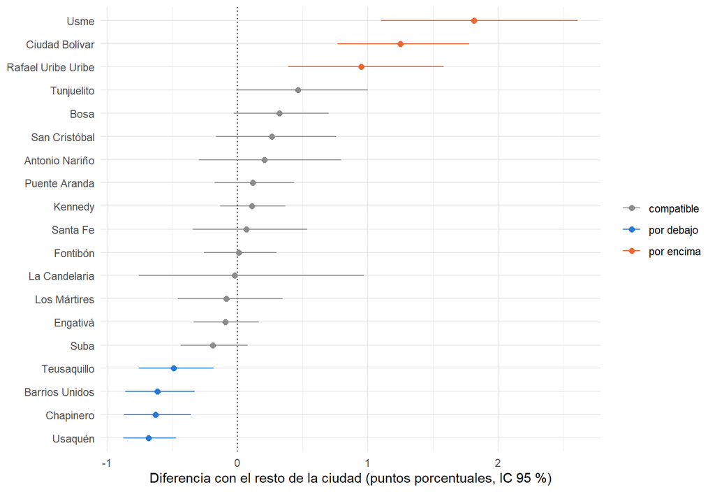

```r
ggplot(contr %>% filter(localidad != "Sumapaz"),
       aes(dif_pp, reorder(localidad, dif_pp), colour = veredicto)) +
  geom_vline(xintercept = 0, linetype = "dotted") +
  geom_errorbarh(aes(xmin = dif_li, xmax = dif_ls), height = 0) + geom_point(size = 2) +
  scale_colour_manual(values = c("por encima" = "#eb6834", compatible = "gray55", "por debajo" = "#2a78d6"), name = NULL) +
  labs(x = "Diferencia con el resto de la ciudad (puntos porcentuales, IC 95 %)", y = NULL) + theme_minimal()
```

Este contraste usa la incertidumbre de **ambos** lados y no depende de fijar $p_0$. Con el criterio del 95 % central coincide con la clasificación anterior: **tres por encima** (Usme, Ciudad Bolívar, Rafael Uribe Uribe) y **cuatro por debajo** (Teusaquillo, Barrios Unidos, Chapinero, Usaquén). Pero hay **dos casos de frontera**: Tunjuelito (0,974) y Bosa (0,964) quedan apenas por debajo de 0,975. Si se usara un criterio unilateral de 0,95 (equivalente a un intervalo del 90 %) serían “por encima”. **La clasificación de esas dos depende del umbral elegido**, y por eso se reporta la probabilidad y no solo el veredicto. Sumapaz (6 siniestros) es compatible por falta de datos, no porque se parezca a la ciudad.

## 9.5 Comparaciones directas entre localidades

Para preguntas como “¿Usme es más mortal que Ciudad Bolívar?” el contraste se hace **entre las dos posteriores** (prior histórica, simulación conjunta):

```r
cand <- c("Usme", "Ciudad Bolívar", "Rafael Uribe Uribe", "Tunjuelito", "Kennedy", "Usaquén")
muestras <- lapply(cand, function(nm) { r <- tab[tab$localidad == nm, ]; rbeta(NS, aH + r$y, bH + r$n - r$y) })
names(muestras) <- cand
Pm <- outer(cand, cand, Vectorize(function(a, b) if (a == b) NA else mean(muestras[[a]] > muestras[[b]])))
dimnames(Pm) <- list(`fila: ¿es mayor que...` = cand, `columna` = cand)
round(Pm, 3)
```

```
##                       columna
## fila: ¿es mayor que...  Usme Ciudad Bolívar Rafael Uribe Uribe Tunjuelito
##     Usme                  NA          0,896              0,961      0,999
##     Ciudad Bolívar     0,104             NA              0,758      0,981
##     Rafael Uribe Uribe 0,039          0,242                 NA      0,888
##     Tunjuelito         0,001          0,019              0,112         NA
##     Kennedy            0,000          0,000              0,003      0,102
##     Usaquén            0,000          0,000              0,000      0,000
##                       columna
## fila: ¿es mayor que... Kennedy Usaquén
##     Usme                 1,000       1
##     Ciudad Bolívar       1,000       1
##     Rafael Uribe Uribe   0,997       1
##     Tunjuelito           0,898       1
##     Kennedy                 NA       1
##     Usaquén              0,000      NA
```

Cada celda es $P(p_{\text{fila}} > p_{\text{columna}}\mid\text{datos})$. Por ejemplo, la probabilidad de que Usme sea más mortal que Ciudad Bolívar es 0,9: es probable pero **no concluyente**, a diferencia de Usme frente a Kennedy (1). Entre Kennedy y Usaquén la probabilidad de que Kennedy sea mayor es 1.

# 10 La cuarentena de 2020

```r
yN <- sum(rec$y); nN <- nrow(rec); yC <- sum(cua$y); nC <- nrow(cua)
aN <- 1 + yN; bN <- 1 + nN - yN; aC <- 1 + yC; bC <- 1 + nC - yC
rbind(normal = resumen(aN, bN), cuarentena = resumen(aC, bC))
```

```
##               a     b      media         li         ls p_mayor_p0
## normal     1235 86696 0,01404510 0,01327783 0,01483331  0,5074100
## cuarentena  128  6597 0,01903346 0,01590553 0,02243220  0,9994762
```

```r
set.seed(2026)
sN <- rbeta(200000, aN, bN); sC <- rbeta(200000, aC, bC)
c(prob_cua_mayor = mean(sC > sN), dif_media = mean(sC - sN), quantile(sC - sN, c(0.025, 0.975)),
  razon_media = mean(sC / sN), quantile(sC / sN, c(0.025, 0.975)))
```

```
## prob_cua_mayor      dif_media           2,5%          97,5%    razon_media
##    0,999055000    0,004984012    0,001754859    0,008459899    1,355935385
##           2,5%          97,5%
##    1,123003807    1,612427233
```

Normal: media 1,40 % [1,33 %; 1,48 %]. Cuarentena: media 1,90 % [1,59 %; 2,24 %]. P(p cuarentena > p normal | datos) = 0,999. En cuarentena un siniestro fue 36 % más mortal (razón 1,36, entre 1,12 y 1,61): con calles vacías hubo menos siniestros, pero más graves.

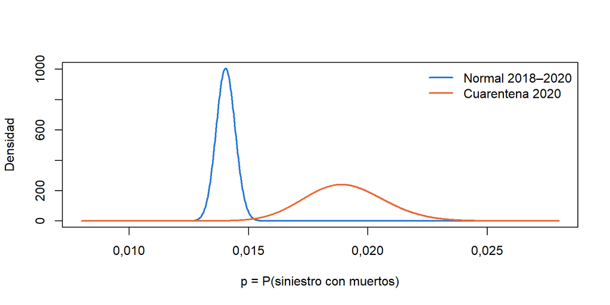

```r
curve(dbeta(x, aN, bN), from = 0.008, to = 0.028, n = 1000, lwd = 2, col = "#2a78d6",
      xlab = "p = P(siniestro con muertos)", ylab = "Densidad")
curve(dbeta(x, aC, bC), add = TRUE, n = 1000, lwd = 2, col = "#eb6834")
legend("topright", c("Normal 2018–2020", "Cuarentena 2020"), col = c("#2a78d6", "#eb6834"), lwd = 2, bty = "n")
```

# 11 Sensibilidad a la prior

Una prior Beta(a, b) funciona como siniestros imaginarios: *a* con muertos y *b* sin muertos que “ya se habían visto”. Pesa como a + b siniestros. Con muchos datos se diluye; con pocos, manda.

## 11.1 Por localidad: cuatro priors

- **Uniforme** y **Jeffreys**: dos formas estándar de decir “no sé nada”.
- **Histórica (principal)**: la de la sección anterior, 286 siniestros imaginarios.
- **Escéptica**: cree que la localidad es igual a Bogotá (p₀) con tanto peso como sus propios datos.

```r
sens_loc <- function(cod) {
  dd <- rec %>% filter(CODIGO_LOCALIDAD == cod); y <- sum(dd$y); n <- nrow(dd)
  pr <- list(uniforme = c(1, 1), jeffreys = c(0.5, 0.5), historica = c(aH, bH),
             esceptica = c(1 + n * p0, 1 + n * (1 - p0)))
  t(sapply(pr, function(ab) c(peso = sum(ab), datos = n,
                              resumen(ab[1] + y, ab[2] + n - y)[c("media", "li", "ls", "p_mayor_p0")])))
}
sens_loc(5)    # Usme, 1.811 siniestros
```

```
##               peso datos      media         li         ls p_mayor_p0
## uniforme     2,000  1811 0,03474903 0,02681820 0,04365113  1,0000000
## jeffreys     1,000  1811 0,03449227 0,02658979 0,04336708  1,0000000
## historica  285,895  1811 0,03176245 0,02469053 0,03967957  1,0000000
## esceptica 1813,000  1811 0,02439726 0,01962830 0,02966306  0,9999991
```

```r
sens_loc(8)    # Kennedy, 9.793
```

```
##               peso datos      media         li         ls p_mayor_p0
## uniforme     2,000  9793 0,01510975 0,01278918 0,01761778  0,8070392
## jeffreys     1,000  9793 0,01506024 0,01274347 0,01756451  0,7956771
## historica  285,895  9793 0,01504158 0,01275789 0,01750749  0,7948623
## esceptica 9795,000  9793 0,01457195 0,01294132 0,01629646  0,7312722
```

```r
sens_loc(17)   # La Candelaria, 407
```

```
##              peso datos      media          li         ls p_mayor_p0
## uniforme    2,000   407 0,01466993 0,005415419 0,02836577  0,4897898
## jeffreys    1,000   407 0,01348039 0,004702663 0,02671570  0,4071007
## historica 285,895   407 0,01385857 0,006556618 0,02379900  0,4424307
## esceptica 409,000   407 0,01435277 0,007377076 0,02356974  0,4925906
```

```r
sens_loc(20)   # Sumapaz, 6
```

```
##              peso datos      media         li         ls p_mayor_p0
## uniforme    2,000     6 0,50000000 0,18405157 0,81594843  0,9999987
## jeffreys    1,000     6 0,50000000 0,16680820 0,83319180  0,9999941
## historica 285,895     6 0,02604543 0,01105450 0,04713249  0,9246417
## esceptica   8,000     6 0,29172888 0,09467997 0,54480654  0,9999814
```

- **Usme y Kennedy:** la conclusión no cambia con ninguna prior. Usme queda por encima de p₀ incluso con la escéptica (media 2,44 %, intervalo [1,96 %; 2,97 %]).
- **La Candelaria (407 siniestros, 5 con muertos):** la media va de 1,35 % a 1,47 %, pero todas concluyen lo mismo: no se distingue de la ciudad.
- **Sumapaz (6 siniestros, 3 con muertos):** con la uniforme la media es 50 %; con la histórica, 2,6 %. **Aquí la prior lo decide todo**: seis siniestros no alcanzan para decir nada por sí solos.

## 11.2 Cuarentena: como la temporada sin público

Tres opiniones de partida antes de ver la cuarentena: uniforme, y dos que creen que la cuarentena será normal (1,40 %), con el peso de media cuarentena y de una cuarentena completa.

```r
m0 <- aN / (aN + bN)
prior_hist <- function(peso) c(1 + peso * m0, 1 + peso * (1 - m0))
priors <- list(uniforme = c(1, 1), media_cuarentena = prior_hist(round(nC / 2)), una_cuarentena = prior_hist(nC))
t(sapply(priors, function(ab) {
  a <- ab[1] + yC; b <- ab[2] + nC - yC
  c(prior_a = ab[1], prior_b = ab[2], prior_media = ab[1] / sum(ab),
    resumen(a, b)[c("media", "li", "ls")], p_mayor_normal = 1 - pbeta(m0, a, b))
}))
```

```
##                   prior_a  prior_b prior_media      media         li         ls
## uniforme          1,00000    1,000  0,50000000 0,01903346 0,01590553 0,02243220
## media_cuarentena 48,21964 3315,780  0,01433402 0,01737084 0,01491323 0,02000965
## una_cuarentena   95,42523 6629,575  0,01418963 0,01653965 0,01445309 0,01876237
##                  p_mayor_normal
## uniforme              0,9994609
## media_cuarentena      0,9966630
## una_cuarentena        0,9910884
```

No depende de la prior que la cuarentena fue más mortal: aun quien arranca convencido de que sería normal, con el peso de 6.725 siniestros, termina con media 1,65 % e intervalo [1,45 %; 1,88 %], que no toca la media normal (1,40 %). P(p > normal) va de 0,991 a 0,999.

# 12 Validación predictiva

Se ajusta el modelo **sin** el periodo que se quiere predecir (2018–2019) y se compara con lo observado. La predictiva posterior es una Beta–Binomial.

```r
pred_bb <- function(nn, a, b) {
  k <- 0:nn
  pr <- exp(lchoose(nn, k) + lbeta(k + a, nn - k + b) - lbeta(a, b)); pr / sum(pr)
}
valida <- function(ent, obj, a0 = 1, b0 = 1) {
  a <- a0 + sum(ent$y); b <- b0 + nrow(ent) - sum(ent$y)
  nn <- nrow(obj); yo <- sum(obj$y); pr <- pred_bb(nn, a, b); cdf <- cumsum(pr)
  c(n = nn, observado = yo, esperado = sum((0:nn) * pr),
    li = min(which(cdf >= 0.025)) - 1, ls = min(which(cdf >= 0.975)) - 1,
    p_cola_superior = sum(pr[(yo + 1):(nn + 1)]))
}
ent <- rec %>% filter(anio <= 2019)
rbind(`Bogota 2020 normal` = valida(ent, rec %>% filter(anio == 2020)),
      `Bogota cuarentena`  = valida(ent, cua),
      `Usme 2020 normal`   = valida(ent %>% filter(CODIGO_LOCALIDAD == 5),
                                    rec %>% filter(anio == 2020, CODIGO_LOCALIDAD == 5), aH, bH),
      `Kennedy 2020 normal` = valida(ent %>% filter(CODIGO_LOCALIDAD == 8),
                                     rec %>% filter(anio == 2020, CODIGO_LOCALIDAD == 8), aH, bH))
```

```
##                         n observado  esperado  li  ls p_cola_superior
## Bogota 2020 normal  15986       242 220,64213 189 253    0,1019350393
## Bogota cuarentena    6723       127  92,79226  74 113    0,0006937956
## Usme 2020 normal      387        11  12,58450   6  21    0,6904887763
## Kennedy 2020 normal  1854        35  26,28375  16  38    0,0778435171
```

2020 sin cuarentena queda dentro del rango del 95 % en Bogotá (242 en [189; 253]), Usme (11 en [6; 21]) y Kennedy (35 en [16; 38]). La cuarentena queda muy por fuera: 127 frente a [74; 113]; si hubiera sido un periodo normal, ver 127 o más tendría probabilidad 0,0007.

# 13 MODELO 2 · Gamma–Poisson: siniestros con muertos por día

Ahora la variable es cuántos siniestros con muertos hay en un día. Si siguen una Poisson(λ) y la prior de λ es Gamma(α, β), la posterior es Gamma(α + total, β + días).

```r
conteo <- function(dd, dias) as.integer(table(factor(as.character(dd$fecha[dd$y == 1]), levels = as.character(dias))))
dias_cua  <- seq(as.Date("2020-03-25"), as.Date("2020-08-31"), by = "day")
dias_rec  <- setdiff(seq(as.Date("2018-01-01"), as.Date("2020-12-31"), by = "day"), dias_cua)
dias_rec  <- as.Date(dias_rec, origin = "1970-01-01")
dias_hist <- seq(as.Date("2015-01-01"), as.Date("2017-12-31"), by = "day")
cN <- conteo(rec, dias_rec); cC <- conteo(cua, dias_cua); cH <- conteo(hist, dias_hist)
cU <- conteo(usm, dias_rec); cHU <- conteo(hist %>% filter(CODIGO_LOCALIDAD == 5), dias_hist)
c(dias_normales = length(cN), lambda_normal = mean(cN), dias_cuarentena = length(cC), lambda_cua = mean(cC))
```

```
##   dias_normales   lambda_normal dias_cuarentena      lambda_cua
##      936,000000        1,318376      160,000000        0,793750
```

## 13.1 ¿Es Poisson? Bondad de ajuste e índice de dispersión

```r
gof_pois <- function(X) {
  J <- length(X); lam <- mean(X); kmax <- max(X)
  obs <- tabulate(X + 1, nbins = kmax + 1); esp <- J * dpois(0:kmax, lam)
  esp[kmax + 1] <- esp[kmax + 1] + J * ppois(kmax, lam, lower.tail = FALSE)
  hi <- kmax + 1; while (sum(esp[hi:(kmax + 1)]) < 5) hi <- hi - 1
  O <- c(obs[seq_len(hi - 1)], sum(obs[hi:(kmax + 1)])); E <- c(esp[seq_len(hi - 1)], sum(esp[hi:(kmax + 1)]))
  chi2 <- sum((O - E)^2 / E); gl <- length(O) - 2
  D <- (J - 1) * var(X) / lam
  c(dias = J, lambda = lam, varianza = var(X), indice = var(X) / lam, chi2 = chi2, gl = gl,
    p_valor = if (gl > 0) pchisq(chi2, gl, lower.tail = FALSE) else NA,
    p_dispersion = 2 * min(pchisq(D, J - 1), pchisq(D, J - 1, lower.tail = FALSE)))
}
rbind(normal = gof_pois(cN), cuarentena = gof_pois(cC), usme = gof_pois(cU), historico = gof_pois(cH))
```

```
##            dias     lambda   varianza    indice       chi2 gl    p_valor
## normal      936 1,31837607 1,38088121 1,0474107 1,57550121  4 0,81318843
## cuarentena  160 0,79375000 0,61757075 0,7780419 6,64166691  2 0,03612271
## usme        936 0,06623932 0,06405686 0,9670519 0,01812625  0         NA
## historico  1096 1,49087591 1,46293037 0,9812556 1,86640662  4 0,76031312
##            p_dispersion
## normal       0,30550795
## cuarentena   0,03487504
## usme         0,48086449
## historico    0,66930917
```

```r
tapply(cN, weekdays(dias_rec), mean)     # efecto del dia de la semana
```

```
##   domingo    jueves     lunes    martes miércoles    sábado   viernes
##  1,127820  1,291045  1,194030  1,281481  1,194030  1,639098  1,503759
```

Días normales: `chi2 = 1,58`, `gl = 4`, `p = 0,81`, índice de dispersión 1,05 (`p = 0,31`): **el conteo diario es Poisson.** En la cuarentena el ajuste es peor (`p = 0,036`) y hay subdispersión (índice 0,78): hubo menos días con 0 y menos con 3 o más de lo que espera la Poisson. Se reporta como limitación. Viernes y sábados tienen más siniestros con muertos (1,50 y 1,64 por día) que los domingos (1,13).

## 13.2 Posterior de λ

```r
g0 <- c(0.001, 0.001)                                        # Gamma vaga
gpost <- function(X, a0 = g0[1], b0 = g0[2]) c(a0 + sum(X), b0 + length(X))
gres  <- function(ab) c(a = ab[1], b = ab[2], media = ab[1] / ab[2],
                        li = qgamma(0.025, ab[1], ab[2]), ls = qgamma(0.975, ab[1], ab[2]))
GN <- gpost(cN); GC <- gpost(cC); GU <- gpost(cU)
rbind(normal = gres(GN), cuarentena = gres(GC), usme = gres(GU))
```

```
##                   a       b      media         li         ls
## normal     1234,001 936,001 1,31837573 1,24583488 1,39294029
## cuarentena  127,001 160,001 0,79375129 0,66171518 0,93762001
## usme         62,001 936,001 0,06624031 0,05078618 0,08371591
```

```r
set.seed(2026)
lN <- rgamma(200000, GN[1], GN[2]); lC <- rgamma(200000, GC[1], GC[2])
c(prob_cua_menor = mean(lC < lN), dif = mean(lN - lC), quantile(lN - lC, c(0.025, 0.975)))
```

```
## prob_cua_menor            dif           2,5%          97,5%
##      1,0000000      0,5247857      0,3640238      0,6757752
```

Normal: 1,32 siniestros con muertos por día [1,25; 1,39]. Cuarentena: 0,79 [0,66; 0,94]. Usme: 0,066 por día (uno cada 15 días). La cuarentena tuvo menos siniestros fatales por día (0,52 menos, entre 0,36 y 0,68) aunque cada siniestro fuera más mortal: las dos cosas pasan a la vez porque el número total de siniestros cayó mucho más.

## 13.3 Priors no informativas e informativas para λ

```r
sens_g <- function(X, lam_hist) {
  pr <- list(vaga = c(0.001, 0.001), jeffreys = c(0.5, 0), historica_30_dias = c(lam_hist * 30, 30),
             historica_peso_datos = c(lam_hist * length(X), length(X)))
  t(sapply(pr, function(ab) c(prior_a = ab[1], prior_b = ab[2], gres(ab + c(sum(X), length(X)))[c("media", "li", "ls")])))
}
sens_g(cC, mean(cH))      # cuarentena, prior historica de Bogota (1,49 por dia)
```

```
##                        prior_a prior_b     media        li        ls
## vaga                   0,00100   0,001 0,7937513 0,6617152 0,9376200
## jeffreys               0,50000   0,000 0,7968750 0,6645670 0,9410158
## historica_30_dias     44,72628  30,000 0,9038225 0,7736943 1,0439166
## historica_peso_datos 238,54015 160,000 1,1423130 1,0281980 1,2623465
```

```r
sens_g(cU, mean(cHU))     # Usme, prior historica de Usme
```

```
##                        prior_a prior_b      media         li         ls
## vaga                  0,001000   0,001 0,06624031 0,05078618 0,08371591
## jeffreys              0,500000   0,000 0,06677350 0,05125306 0,08431544
## historica_30_dias     1,614964  30,000 0,06585400 0,05067294 0,08299381
## historica_peso_datos 50,386861 936,000 0,06003572 0,04945059 0,07163211
```

Con 160 días la prior histórica de peso 30 días sube la media de la cuarentena de 0,79 a 0,90; con el peso de los 160 días, a 1,14. Aun así queda por debajo de 1,32. En Usme (936 días) la prior casi no importa salvo cuando pesa tanto como los datos.

## 13.4 Predictiva posterior: Binomial Negativa

```r
# un dia: NB(a, b / (b + 1)); una semana: NB(a, b / (b + 7))
pred_dia <- function(G) c(dnbinom(0:2, G[1], G[2] / (G[2] + 1)), `3+` = pnbinom(2, G[1], G[2] / (G[2] + 1), lower.tail = FALSE))
rbind(normal = pred_dia(GN), cuarentena = pred_dia(GC))
```

```
##                                                  3+
## normal     0,2677579 0,3526288 0,2323887 0,14722454
## cuarentena 0,4532637 0,3575440 0,1421295 0,04706269
```

```r
c(dnbinom(0:2, GU[1], GU[2] / (GU[2] + 7)), `3+` = pnbinom(2, GU[1], GU[2] / (GU[2] + 7), lower.tail = FALSE))  # Usme, semana
```

```
##                                          3+
## 0,63004947 0,28997411 0,06780513 0,01217129
```

```r
# chequeos predictivos: simular anios completos y comparar con lo observado
set.seed(2026); S <- 4000
lam_s <- rgamma(S, GN[1], GN[2])
sim <- matrix(rpois(S * 365, rep(lam_s, each = 365)), nrow = S, byrow = TRUE)
est <- function(X) c(pct_cero = mean(X == 0), pct_3mas = mean(X >= 3), maximo = max(X), varianza = var(X))
obs <- est(cN); ss <- t(apply(sim, 1, est))
rbind(observado = obs, sim_media = colMeans(ss),
      sim_li = apply(ss, 2, quantile, 0.025), sim_ls = apply(ss, 2, quantile, 0.975),
      p_bayes = colMeans(sweep(ss, 2, obs, ">=")))
```

```
##            pct_cero  pct_3mas  maximo varianza
## observado 0,2617521 0,1442308 8,00000 1,380881
## sim_media 0,2670575 0,1475452 5,75250 1,318212
## sim_li    0,2191781 0,1068493 5,00000 1,104211
## sim_ls    0,3178082 0,1890411 8,00000 1,562371
## p_bayes   0,5692500 0,5640000 0,02625 0,291750
```

```r
quantile(rowSums(sim), c(0.025, 0.5, 0.975))     # total de un anio; 2019 tuvo 492
```

```
##  2,5%   50% 97,5%
##   430   482   533
```

# 14 Intervalos de credibilidad: colas iguales frente a HPD

```r
hpd <- function(qf, mass = 0.95) {
  f <- function(q) qf(q + mass) - qf(q)
  q <- optimize(f, c(0, 1 - mass))$minimum
  c(hpd_li = qf(q), hpd_ls = qf(q + mass))
}
casos <- list(
  p_usme       = function(q) qbeta(q, aH + yU, bH + nU - yU),
  p_cuarentena = function(q) qbeta(q, aC, bC),
  p_candelaria_hist = function(q) qbeta(q, aH + 5, bH + 402),     # prior histórica (la principal)
  p_candelaria_unif = function(q) qbeta(q, 1 + 5, 1 + 402),       # uniforme (solo para ver la asimetría)
  p_sumapaz_hist    = function(q) qbeta(q, aH + 3, bH + 3),
  p_sumapaz_unif    = function(q) qbeta(q, 1 + 3, 1 + 3),
  l_normal     = function(q) qgamma(q, GN[1], GN[2]),
  l_cuarentena = function(q) qgamma(q, GC[1], GC[2]),
  l_usme       = function(q) qgamma(q, GU[1], GU[2]))
hpd_tab <- t(sapply(casos, function(qf) { h <- hpd(qf); ci <- qf(c(0.025, 0.975))
  c(ci_li = ci[1], ci_ls = ci[2], h, reduccion_pct = 100 * (1 - diff(h) / diff(ci))) }))
hpd_tab
```

```
##                         ci_li      ci_ls      hpd_li     hpd_ls
## p_usme            0,024690527 0,03967957 0,024416985 0,03936055
## p_cuarentena      0,015905531 0,02243220 0,015816109 0,02233207
## p_candelaria_hist 0,006556618 0,02379900 0,005850290 0,02270195
## p_candelaria_unif 0,005415419 0,02836577 0,004349182 0,02646025
## p_sumapaz_hist    0,011054500 0,04713249 0,009488350 0,04456412
## p_sumapaz_unif    0,184051568 0,81594843 0,184051568 0,81594843
## l_normal          1,245834877 1,39294029 1,245140016 1,39221893
## l_cuarentena      0,661715182 0,93762001 0,657816217 0,93323756
## l_usme            0,050786185 0,08371591 0,050137373 0,08294871
##                   reduccion_pct.hpd_ls
## p_usme                       0,3033922
## p_cuarentena                 0,1640575
## p_candelaria_hist            2,2660492
## p_candelaria_unif            3,6569553
## p_sumapaz_hist               2,7779215
## p_sumapaz_unif               0,0000000
## l_normal                     0,0180105
## l_cuarentena                 0,1752358
## l_usme                       0,3595067
```

Con posteriores casi simétricas (Usme, Bogotá, λ) los dos intervalos prácticamente coinciden: el HPD es menos del 0,4 % más angosto. La ventaja del HPD aparece donde hay **pocos datos**, porque la posterior queda asimétrica: con la **prior histórica** (la que usa el resto del informe) es de 2,3 % en La Candelaria (5 de 407) y de 2,8 % en Sumapaz; con la **uniforme**, en La Candelaria sube a 3,7 % y el HPD se corre hacia la izquierda ([0,43 %; 2,65 %] frente a [0,54 %; 2,84 %]). En Sumapaz con la uniforme la posterior Beta(4, 4) es simétrica y los dos intervalos coinciden exactamente. *(Se indica la prior de cada fila porque en versiones anteriores se mezclaban la uniforme y la histórica entre tablas.)*

# 15 Teoría de la decisión: cinco funciones de pérdida

El decisor es la Secretaría de Movilidad. Subestimar la mortalidad de una localidad (y no intervenir) cuesta más que sobreestimarla: k₁ = 3 por subestimar y k₂ = 1 por sobreestimar. La LINEX con a < 0 también castiga más la subestimación.

```r
K1 <- 3; K2 <- 1
bayes_beta <- function(a, b, aL) {
  E <- integrate(function(t) exp(-aL * t) * dbeta(t, a, b),
                 qbeta(1e-12, a, b), qbeta(1 - 1e-12, a, b))$value   # donde esta la masa
  c(cuadratica = a / (a + b), cuad_relativa = (a - 2) / (a + b - 2),
    lineal_asim = qbeta(K1 / (K1 + K2), a, b), todo_nada = (a - 1) / (a + b - 2), linex = -log(E) / aL)
}
bayes_gamma <- function(a, b, aL) c(cuadratica = a / b, cuad_relativa = (a - 2) / b,
  lineal_asim = qgamma(K1 / (K1 + K2), a, b), todo_nada = (a - 1) / b, linex = (a / aL) * log(1 + aL / b))

A_P <- -200; A_L <- -20
est <- rbind(
  p_usme       = bayes_beta(aH + yU, bH + nU - yU, A_P),
  p_kennedy    = bayes_beta(aH + yK, bH + nK - yK, A_P),
  p_candelaria = bayes_beta(aH + 5, bH + 402, A_P),
  p_cuarentena = bayes_beta(aC, bC, A_P),
  l_normal     = bayes_gamma(GN[1], GN[2], A_L),
  l_cuarentena = bayes_gamma(GC[1], GC[2], A_L),
  l_usme       = bayes_gamma(GU[1], GU[2], A_L))
cbind(est, rango_relativo = (apply(est, 1, max) - apply(est, 1, min)) / est[, "cuadratica"])
```

```
##              cuadratica cuad_relativa lineal_asim  todo_nada      linex
## p_usme       0,03176245    0,03083808  0,03425825 0,03131543 0,03332162
## p_kennedy    0,01504158    0,01484609  0,01584094 0,01494533 0,01519047
## p_candelaria 0,01385857    0,01100389  0,01654731 0,01245129 0,01629256
## p_cuarentena 0,01903346    0,01874163  0,02012987 0,01889038 0,01931646
## l_normal     1,31837573    1,31623898  1,34349167 1,31730735 1,33266484
## l_cuarentena 0,79375129    0,78125137  0,84005531 0,78750133 0,84792535
## l_usme       0,06624031    0,06410356  0,07170393 0,06517194 0,06695825
##              rango_relativo
## p_usme           0,10767980
## p_kennedy        0,06613968
## p_candelaria     0,39999947
## p_cuarentena     0,07293664
## l_normal         0,02067141
## l_cuarentena     0,08399858
## l_usme           0,11473931
```

```r
sapply(c(-50, -200, -500), function(aL) bayes_beta(aH + yU, bH + nU - yU, aL)["linex"])   # Usme, varios a
```

```
##      linex      linex      linex
## 0,03213448 0,03332162 0,03607764
```

## 15.1 Cada estimador es óptimo bajo *su* pérdida

Las cinco funciones de pérdida son $L(d,p)$: cuadrática $(d-p)^2$; cuadrática relativa $(d-p)^2/p^2$; lineal asimétrica ($k_1 = 3$ si $d<p$, $k_2 = 1$ si $d>p$); todo o nada ($\varepsilon = 0{,}0005$, es decir 0,05 pp) y LINEX con $a = -200$. La tabla cruza los cinco estimadores de Bayes de $p_{\text{Usme}}$ (filas) con las cinco pérdidas (columnas): cada celda es la **pérdida esperada posterior dividida por la mínima de su columna** (1,00 = óptimo bajo esa pérdida).

```r
eps_tn <- 0.0005
perd_esp <- function(d, a, b, tipo) {                    # E[L(d, p) | datos] con p ~ Beta(a, b)
  if (tipo == "todo") return(1 - (pbeta(d + eps_tn, a, b) - pbeta(d - eps_tn, a, b)))
  f <- switch(tipo,
    cuad  = function(t) (d - t)^2,
    rel   = function(t) (d - t)^2 / t^2,
    lin   = function(t) ifelse(d > t, K2 * (d - t), K1 * (t - d)),
    linex = function(t) exp(A_P * (d - t)) - A_P * (d - t) - 1)
  integrate(function(t) f(t) * dbeta(t, a, b), qbeta(1e-12, a, b), qbeta(1 - 1e-12, a, b),
            subdivisions = 500, rel.tol = 1e-8)$value
}
aU <- aH + yU; bU <- bH + nU - yU
d_est <- est["p_usme", ]                                  # los cinco estimadores de Bayes para Usme
tipos <- c(cuad = "cuad", rel = "rel", lin = "lin", todo = "todo", linex = "linex")
Mx <- sapply(tipos, function(tp) sapply(d_est, function(d) perd_esp(d, aU, bU, tp)))
rownames(Mx) <- names(d_est)
round(sweep(Mx, 2, apply(Mx, 2, min), "/"), 3)
```

```
##                cuad   rel   lin  todo linex
## cuadratica    1,000 1,060 1,224 1,001 1,173
## cuad_relativa 1,058 1,000 1,434 1,001 1,470
## lineal_asim   1,425 1,820 1,000 1,029 1,053
## todo_nada     1,014 1,016 1,317 1,000 1,296
## linex         1,166 1,433 1,029 1,014 1,000
```

La diagonal vale ≈ 1,000: **cada estimador es el mejor bajo su propia pérdida** Fuera de la diagonal, usar el estimador “equivocado” cuesta entre poco y bastante, según la pérdida del decisor: por ejemplo, reportar la media cuando el decisor penaliza más subestimar tiene una pérdida esperada 22 % mayor que reportar el cuantil 0,75. Esto es lo que da sentido a H5: **qué se reporta depende de cuánto cuesta equivocarse y en qué dirección**.

## 15.2 ¿Intervenir una localidad?

Se interviene si la probabilidad de que la localidad sea de alto riesgo (p > 1,5 · p₀ = 2,1 %) supera c₁ / (c₁ + c₂). Si intervenir sin necesidad cuesta c₁ = 1 y no intervenir cuando hacía falta cuesta c₂ = 3, el umbral es 0,25.

```r
C1 <- 1; C2 <- 3
tab %>% mutate(p_alto = 1 - pbeta(1.5 * p0, a, b), intervenir = p_alto > C1 / (C1 + C2)) %>%
  select(localidad, n, y, media, p_alto, intervenir) %>% arrange(desc(p_alto))
```

```
## # A tibble: 20 × 6
##    localidad              n     y   media   p_alto intervenir
##    <chr>              <int> <int>   <dbl>    <dbl> <lgl>
##  1 Usme                1811    62 0.0318  9.99e- 1 TRUE
##  2 Ciudad Bolívar      3581    96 0.0260  9.79e- 1 TRUE
##  3 Rafael Uribe Uribe  2230    54 0.0233  7.67e- 1 TRUE
##  4 Sumapaz                6     3 0.0260  6.75e- 1 TRUE
##  5 Tunjuelito          2550    48 0.0185  1.61e- 1 FALSE
##  6 La Candelaria        407     5 0.0139  6.60e- 2 FALSE
##  7 Antonio Nariño      1802    29 0.0161  4.46e- 2 FALSE
##  8 San Cristóbal       2697    45 0.0166  3.67e- 2 FALSE
##  9 Bosa                4781    82 0.0171  1.96e- 2 FALSE
## 10 Santa Fe            2675    39 0.0147  4.93e- 3 FALSE
## 11 Los Mártires        2929    38 0.0133  4.02e- 4 FALSE
## 12 Puente Aranda       6291    95 0.0151  1.98e- 4 FALSE
## 13 Kennedy             9793   147 0.0150  4.26e- 6 FALSE
## 14 Fontibón            7241   102 0.0142  4.24e- 6 FALSE
## 15 Engativá            8761   115 0.0132  1.11e- 8 FALSE
## 16 Suba                7542    92 0.0123  2.54e- 9 FALSE
## 17 Teusaquillo         4540    41 0.00945 1.18e-10 FALSE
## 18 Barrios Unidos      4618    36 0.00828 4.71e-13 FALSE
## 19 Chapinero           4947    38 0.00814 4.15e-14 FALSE
## 20 Usaquén             8727    67 0.00794 0        FALSE
```

Se intervienen Usme (0,999), Ciudad Bolívar (0,98) y Rafael Uribe Uribe (0,77). Sumapaz también pasa el umbral (0,68), pero con solo 6 siniestros esa decisión la toma casi entera la prior.

### 15.2.1 La decisión con riesgo y pérdida explícitos

Lo anterior fija un umbral de “alto riesgo” sin justificarlo. Aquí se hace explícito:

**Riesgo.** Se define el riesgo de una localidad como su **exceso de letalidad sobre la ciudad**: $p_j - p_0$. Una localidad es de **alto riesgo** si $p_j > p^* = k\,p_0$. Se toma $k = 1{,}5$ (un siniestro al menos 50 % más mortal que el promedio, es decir $p^* = 2{,}10\,\%$); es un supuesto del decisor y por eso se prueba con otros valores.

**Decisión y pérdida.** El decisor elige entre *intervenir* ($a_1$) y *no intervenir* ($a_0$), con pérdida

|  | $p_j \le p^*$ (no es de alto riesgo) | $p_j > p^*$ (alto riesgo) |
| --- | --- | --- |
| Intervenir ($a_1$) | $c_1$ (intervención innecesaria) | 0 |
| No intervenir ($a_0$) | 0 | $c_2$ (omisión: muertes evitables) |

La pérdida esperada posterior es $E[L(a_1)] = c_1\,P(p_j\le p^*\mid\text{datos})$ y $E[L(a_0)] = c_2\,P(p_j>p^*\mid\text{datos})$, así que **se interviene si $P(p_j>p^*\mid\text{datos}) > c_1/(c_1+c_2)$**. Con $c_1 = 1$ y $c_2 = 3$ (omitir cuesta el triple, porque cada siniestro con muertos es irreversible) el umbral es 0,25.

Como la decisión depende de $k$ y de $c_2/c_1$, se reporta cuántas localidades se intervienen en una **rejilla de supuestos**, y también el **exceso esperado de letalidad** $E[(p_j-p_0)^+]$, que no depende de ningún umbral y sirve para ordenar:

```r
dec <- tab %>% rowwise() %>%
  mutate(exceso_pp = 100 * integrate(function(t) pmax(t - p0, 0) * dbeta(t, a, b), 0.001, 0.12, subdivisions = 400)$value) %>%
  ungroup() %>% select(localidad, n, y, media, exceso_pp, a, b)
rej <- expand.grid(k = c(1.25, 1.5, 2), c2c1 = c(2, 3, 5))
res <- do.call(rbind, lapply(seq_len(nrow(rej)), function(i) {
  um <- 1 / (1 + rej$c2c1[i])                                  # c1/(c1+c2) con c1 = 1
  interv <- dec$localidad[(1 - pbeta(rej$k[i] * p0, dec$a, dec$b)) > um]
  data.frame(k = rej$k[i], p_estrella = round(100 * rej$k[i] * p0, 2), c2_sobre_c1 = rej$c2c1[i], umbral = round(um, 2),
             n_intervenidas = length(interv), intervenidas = paste(interv, collapse = ", "))
}))
res
```

```
##      k p_estrella c2_sobre_c1 umbral n_intervenidas
## 1 1,25       1,75           2   0,33              7
## 2 1,50       2,11           2   0,33              4
## 3 2,00       2,81           2   0,33              2
## 4 1,25       1,75           3   0,25              8
## 5 1,50       2,11           3   0,25              4
## 6 2,00       2,81           3   0,25              2
## 7 1,25       1,75           5   0,17              9
## 8 1,50       2,11           5   0,17              4
## 9 2,00       2,81           5   0,17              3
##                                                                                                        intervenidas
## 1                                Usme, Sumapaz, Ciudad Bolívar, Rafael Uribe Uribe, Tunjuelito, Bosa, San Cristóbal
## 2                                                                 Usme, Sumapaz, Ciudad Bolívar, Rafael Uribe Uribe
## 3                                                                                                     Usme, Sumapaz
## 4                Usme, Sumapaz, Ciudad Bolívar, Rafael Uribe Uribe, Tunjuelito, Bosa, San Cristóbal, Antonio Nariño
## 5                                                                 Usme, Sumapaz, Ciudad Bolívar, Rafael Uribe Uribe
## 6                                                                                                     Usme, Sumapaz
## 7 Usme, Sumapaz, Ciudad Bolívar, Rafael Uribe Uribe, Tunjuelito, Bosa, San Cristóbal, Antonio Nariño, La Candelaria
## 8                                                                 Usme, Sumapaz, Ciudad Bolívar, Rafael Uribe Uribe
## 9                                                                                     Usme, Sumapaz, Ciudad Bolívar
```

```r
dec %>% mutate(p_alto = 1 - pbeta(1.5 * p0, a, b), media = round(100 * media, 2), exceso_pp = round(exceso_pp, 3), p_alto = round(p_alto, 3)) %>%
  select(localidad, n, y, media, exceso_pp, p_alto) %>% arrange(desc(exceso_pp)) %>% head(8)
```

```
## # A tibble: 8 × 6
##   localidad              n     y media exceso_pp p_alto
##   <chr>              <int> <int> <dbl>     <dbl>  <dbl>
## 1 Usme                1811    62  3.18     1.77   0.999
## 2 Sumapaz                6     3  2.6      1.22   0.675
## 3 Ciudad Bolívar      3581    96  2.6      1.20   0.979
## 4 Rafael Uribe Uribe  2230    54  2.33     0.926  0.767
## 5 Tunjuelito          2550    48  1.85     0.454  0.161
## 6 Bosa                4781    82  1.71     0.308  0.02
## 7 San Cristóbal       2697    45  1.66     0.273  0.037
## 8 Antonio Nariño      1802    29  1.61     0.239  0.045
```

**Lectura.** De los 9 escenarios, **Usme** se interviene en 9, **Ciudad Bolívar** en 7 y **Rafael Uribe Uribe** en 6 (siempre que el umbral de riesgo sea $k \le 1{,}5$); las demás localidades entran solo con umbrales de riesgo bajos o costos de omisión altos. La lista de localidades intervenidas **no es un resultado de los datos solos**: es el resultado de los datos *y* de la función de pérdida, y por eso se muestra cómo cambia. Sumapaz (6 siniestros) entra en 9 escenarios y siempre por efecto de la prior, no de evidencia propia: la decisión debería confirmarse con más datos.

# 16 Verificación con JAGS

JAGS aproxima la posterior por MCMC (muestreo de Gibbs). En modelos conjugados no hace falta, pero sirve para **comprobar que la teoría y el código coinciden**; después se usa en un modelo que **no** tiene forma cerrada (siguiente sección). Se usan 3 cadenas, 4.000 iteraciones de calentamiento y 40.000 de muestreo; se reporta $\hat R$ (≈ 1 indica convergencia) y el tamaño efectivo de muestra.

```r
correr_jags <- function(modelo, datos, nodos, n.adapt = 2000, burn = 4000, iter = 40000, chains = 3) {
  m <- jags.model(textConnection(modelo), data = datos, n.chains = chains, n.adapt = n.adapt, quiet = TRUE)
  update(m, burn, progress.bar = "none")
  coda.samples(m, nodos, n.iter = iter, progress.bar = "none")
}
```

## 16.1 Beta–Binomial de Usme: JAGS frente a la posterior analítica

```r
mod_bb <- "
model {
  y ~ dbin(p, n)
  p ~ dbeta(a0, b0)
}"
jb <- correr_jags(mod_bb, list(y = yU, n = nU, a0 = aH, b0 = bH), "p")
vb <- as.numeric(as.matrix(jb)); A_ <- aH + yU; B_ <- bH + nU - yU
data.frame(fuente = c("Analítica", "JAGS"),
           media = c(A_ / (A_ + B_), mean(vb)),
           li = c(qbeta(0.025, A_, B_), quantile(vb, 0.025, names = FALSE)),
           ls = c(qbeta(0.975, A_, B_), quantile(vb, 0.975, names = FALSE)),
           P_mayor_p0 = c(1 - pbeta(p0, A_, B_), mean(vb > p0)),
           Rhat = c(NA, gelman.diag(jb)$psrf[1, 1]),
           n_efectivo = c(NA, effectiveSize(jb)))
```

```
##      fuente      media         li         ls P_mayor_p0     Rhat n_efectivo
##   Analítica 0,03176245 0,02469053 0,03967957          1       NA         NA
## p      JAGS 0,03174699 0,02467707 0,03964437          1 1,000008   70877,55
```

## 16.2 Gamma–Poisson: normal frente a cuarentena

El modelo tiene dos tasas, $\lambda_N$ (días normales) y $\lambda_C$ (cuarentena), cada una con la prior Gamma vaga. JAGS también entrega la **diferencia** $\lambda_N - \lambda_C$ y una **predictiva de un día nuevo** en cuarentena, que se compara con la Binomial Negativa analítica.

```r
mod_gp <- "
model {
  for (i in 1:nN) { cN[i] ~ dpois(lamN) }
  for (i in 1:nC) { cC[i] ~ dpois(lamC) }
  lamN ~ dgamma(0.001, 0.001)
  lamC ~ dgamma(0.001, 0.001)
  dif  <- lamN - lamC
  ynuevo ~ dpois(lamC)
}"
jg <- correr_jags(mod_gp, list(cN = cN, nN = length(cN), cC = cC, nC = length(cC)), c("lamN", "lamC", "dif", "ynuevo"))
mg <- as.matrix(jg)
data.frame(cantidad = c("lambda normal (media)", "lambda cuarentena (media)", "lambda cuarentena IC95 inf.",
                        "lambda cuarentena IC95 sup.", "diferencia normal - cuarentena (media)",
                        "P(lambda cuarentena < normal)", "P(día nuevo en cuarentena sin siniestros fatales)"),
           analitica = c(GN[1] / GN[2], GC[1] / GC[2], qgamma(0.025, GC[1], GC[2]), qgamma(0.975, GC[1], GC[2]),
                         GN[1] / GN[2] - GC[1] / GC[2], mean(lC < lN),
                         dnbinom(0, GC[1], GC[2] / (GC[2] + 1))),
           JAGS = c(mean(mg[, "lamN"]), mean(mg[, "lamC"]), quantile(mg[, "lamC"], 0.025, names = FALSE),
                    quantile(mg[, "lamC"], 0.975, names = FALSE), mean(mg[, "dif"]),
                    mean(mg[, "lamC"] < mg[, "lamN"]), mean(mg[, "ynuevo"] == 0)))
```

```
##                                            cantidad analitica      JAGS
## 1                             lambda normal (media) 1,3183757 1,3185393
## 2                         lambda cuarentena (media) 0,7937513 0,7939913
## 3                       lambda cuarentena IC95 inf. 0,6617152 0,6620947
## 4                       lambda cuarentena IC95 sup. 0,9376200 0,9378822
## 5            diferencia normal - cuarentena (media) 0,5246244 0,5245480
## 6                     P(lambda cuarentena < normal) 1,0000000 1,0000000
## 7 P(día nuevo en cuarentena sin siniestros fatales) 0,4532637 0,4526417
```

```r
c(Rhat_lamN = unname(gelman.diag(jg[, "lamN"])$psrf[1, 1]), Rhat_lamC = unname(gelman.diag(jg[, "lamC"])$psrf[1, 1]))
```

```
## Rhat_lamN Rhat_lamC
## 0,9999953 0,9999987
```

**Lectura.** En ambos modelos JAGS reproduce la solución analítica (medias, intervalos, probabilidades y la predictiva coinciden a 2–3 cifras, con $\hat R \approx 1{,}00$ y decenas de miles de muestras efectivas). La implementación en R y la teoría son consistentes.

# 17 Extensión jerárquica: las 19 localidades a la vez

La prior histórica usa la dispersión entre localidades de 2015–2017 para fijar su peso ($a+b \approx 286$) y lo trata como **conocido**. Un modelo **jerárquico** estima ese peso con los propios datos recientes y reparte la incertidumbre: cada localidad tiene su $p_j$, y todas comparten una distribución Beta con media $\mu$ y concentración $\kappa$ desconocidas (**encogimiento parcial**):

$$y_j \mid p_j \sim \text{Bin}(n_j,
p_j),\qquad p_j \sim \text{Beta}\big(\mu\kappa,\
(1-\mu)\kappa\big),\qquad \mu \sim \text{Beta}(1,1),\quad \kappa \sim
\text{Gamma}(1;\,0{,}001).$$

Se ajusta con los datos del periodo reciente (2018–2020 sin cuarentena) de las 19 localidades (sin Sumapaz). No tiene forma cerrada: es el tipo de modelo para el que se usa JAGS.

```r
dh <- rec %>% filter(CODIGO_LOCALIDAD != 20) %>% group_by(CODIGO_LOCALIDAD, localidad) %>%
  summarise(n = n(), y = sum(y), .groups = "drop") %>% arrange(CODIGO_LOCALIDAD)
mod_h <- "
model {
  for (j in 1:J) { y[j] ~ dbin(p[j], n[j]); p[j] ~ dbeta(mu * kappa, (1 - mu) * kappa) }
  mu    ~ dbeta(1, 1)
  kappa ~ dgamma(1, 0.001)
}"
jh <- correr_jags(mod_h, list(y = dh$y, n = dh$n, J = nrow(dh)), c("p", "mu", "kappa"), burn = 6000, iter = 60000)
mh <- as.matrix(jh)
pj <- mh[, paste0("p[", seq_len(nrow(dh)), "]")]
kap <- mh[, "kappa"]
c(Rhat_max_p = max(gelman.diag(jh[, grep("^p\\[", varnames(jh))])$psrf[, 1]),
  Rhat_kappa = unname(gelman.diag(jh[, "kappa"])$psrf[1, 1]),
  kappa_mediana = median(kap), kappa_li = quantile(kap, 0.025, names = FALSE), kappa_ls = quantile(kap, 0.975, names = FALSE),
  mu_media = mean(mh[, "mu"]), peso_historico = peso)
```

```
##     Rhat_max_p     Rhat_kappa  kappa_mediana       kappa_li       kappa_ls
##     1,00011994     1,00002864   451,05564827   204,53608179   895,08913631
##       mu_media peso_historico
##     0,01558388   285,89501860
```

La concentración estimada $\kappa$ tiene mediana 451 (IC 95 %: 205–895), frente al peso histórico de 286 siniestros imaginarios: ambas rutas llevan a un nivel de encogimiento del mismo orden de magnitud.

```r
comp <- dh %>% mutate(crudo = y / n,
                      historica = (aH + y) / (aH + bH + n),
                      jerarquico = colMeans(pj),
                      jer_li = apply(pj, 2, quantile, 0.025), jer_ls = apply(pj, 2, quantile, 0.975),
                      P_mayor_p0 = colMeans(pj > p0),
                      P_es_la_mayor = tabulate(apply(pj, 1, which.max), nbins = nrow(dh)) / nrow(pj)) %>%
  arrange(desc(jerarquico))
comp %>% mutate(across(c(crudo, historica, jerarquico, jer_li, jer_ls), ~ round(100 * .x, 2)),
                across(c(P_mayor_p0, P_es_la_mayor), ~ round(.x, 3))) %>%
  select(localidad, n, y, crudo, historica, jerarquico, jer_li, jer_ls, P_mayor_p0, P_es_la_mayor)
```

```
## # A tibble: 19 × 10
##    localidad         n     y crudo historica jerarquico jer_li jer_ls P_mayor_p0
##    <chr>         <int> <int> <dbl>     <dbl>      <dbl>  <dbl>  <dbl>      <dbl>
##  1 Usme           1811    62  3.42      3.18       3.04   2.35   3.83      1
##  2 Ciudad Bolív…  3581    96  2.68      2.6        2.55   2.08   3.07      1
##  3 Rafael Uribe…  2230    54  2.42      2.33       2.27   1.74   2.88      1
##  4 Tunjuelito     2550    48  1.88      1.85       1.83   1.38   2.34      0.968
##  5 Bosa           4781    82  1.72      1.71       1.7    1.37   2.07      0.958
##  6 San Cristóbal  2697    45  1.67      1.66       1.65   1.23   2.13      0.864
##  7 Antonio Nari…  1802    29  1.61      1.61       1.6    1.12   2.15      0.76
##  8 Puente Aranda  6291    95  1.51      1.51       1.51   1.23   1.82      0.764
##  9 Kennedy        9793   147  1.5       1.5        1.5    1.27   1.75      0.794
## 10 Santa Fe       2675    39  1.46      1.47       1.47   1.08   1.92      0.607
## 11 Fontibón       7241   102  1.41      1.42       1.42   1.17   1.69      0.527
## 12 La Candelaria   407     5  1.23      1.39       1.39   0.71   2.29      0.455
## 13 Los Mártires   2929    38  1.3       1.33       1.33   0.97   1.75      0.342
## 14 Engativá       8761   115  1.31      1.32       1.32   1.1    1.57      0.248
## 15 Suba           7542    92  1.22      1.23       1.24   1.01   1.5       0.097
## 16 Teusaquillo    4540    41  0.9       0.94       0.96   0.71   1.25      0.002
## 17 Barrios Unid…  4618    36  0.78      0.83       0.85   0.61   1.12      0
## 18 Chapinero      4947    38  0.77      0.81       0.84   0.61   1.1       0
## 19 Usaquén        8727    67  0.77      0.79       0.81   0.63   1         0
## # ℹ 1 more variable: P_es_la_mayor <dbl>
```

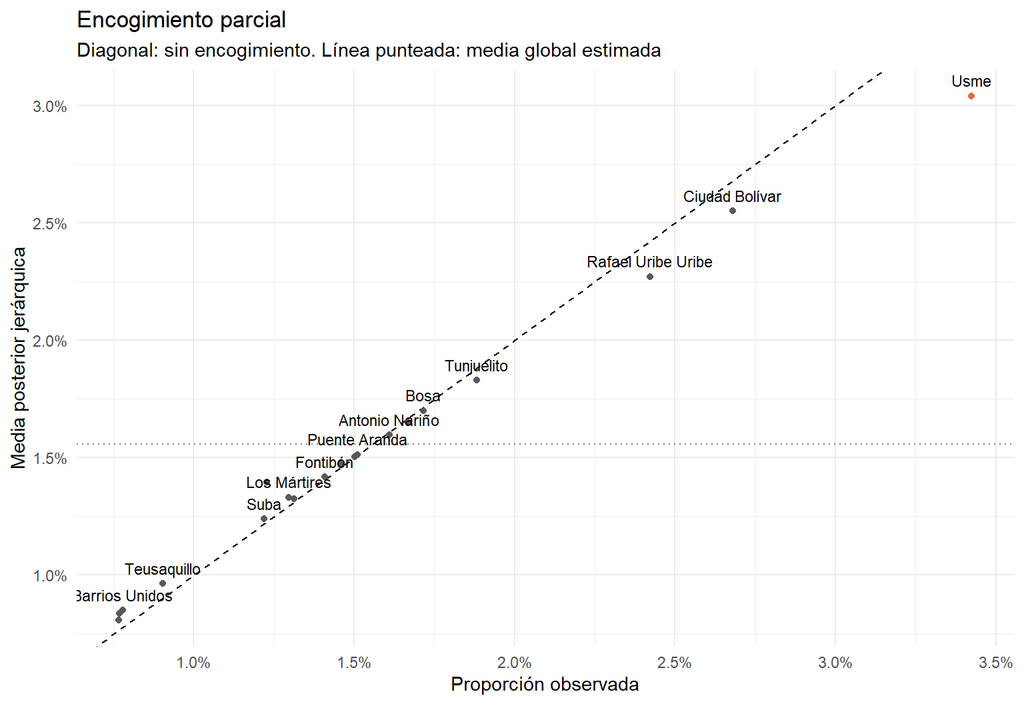

```r
ggplot(comp, aes(crudo, jerarquico, label = localidad)) +
  geom_abline(slope = 1, intercept = 0, linetype = "dashed") +
  geom_hline(yintercept = mean(mh[, "mu"]), linetype = "dotted", colour = "gray50") +
  geom_point(aes(colour = localidad == "Usme"), show.legend = FALSE) +
  geom_text(size = 3, vjust = -0.8, check_overlap = TRUE) +
  scale_colour_manual(values = c("gray35", "#eb6834")) +
  scale_x_continuous(labels = scales::percent) + scale_y_continuous(labels = scales::percent) +
  labs(x = "Proporción observada", y = "Media posterior jerárquica",
       title = "Encogimiento parcial", subtitle = "Diagonal: sin encogimiento. Línea punteada: media global estimada") +
  theme_minimal()
```

## 17.1 Una elección hecha después de ver los datos

Usme se escogió **porque tenía la mayor tasa observada**. Contrastar la localidad más extrema de las 19 exagera la evidencia (es la “maldición del ganador”: parte de lo extremo es azar). El modelo jerárquico lo corrige de dos maneras:

1. **Encoge** la estimación de Usme hacia el centro común: de 3,42 % observado a 3,04 % (IC 95 %: 2,35–3,83 %), frente a 3,18 % con la prior histórica.
2. Responde la pregunta correcta para una elección *a posteriori*: no “¿es Usme distinta de Bogotá?”, sino **¿cuál es la probabilidad de que Usme sea la localidad más mortal?**, que aquí es 0,84.

Aun con el encogimiento, `P(p > p₀ | datos)` para Usme sigue siendo prácticamente 1: **la conclusión de que Usme es más mortal que la ciudad se mantiene**. Lo que cambia es la magnitud, que baja un poco (de 3,42 % a 3,04 %), y que hay que declarar que fue elegida por ser la mayor.

# 18 Resumen de supuestos

| Supuesto | Herramienta | Bogotá | Usme | Kennedy |
| --- | --- | --- | --- | --- |
| Dos resultados | Naturaleza de la variable | Cumple | Cumple | Cumple |
| Número fijo de ensayos | Se condiciona en n · grupos de 50 | Cumple | Cumple | Cumple |
| Independencia | Prueba de rachas | Cumple (p = 0,25) | Cumple (p = 0,53) | Cumple (p = 0,89) |
| Probabilidad constante 2018–2020 | χ² de homogeneidad | Cumple (p = 0,35) | Cumple (p = 0,74) | Cumple (p = 0,28) |
| Forma binomial | χ² de bondad de ajuste | Cumple (p = 0,44) | Cumple (p = 0,66) | Cumple (p = 0,42) |
| Sin sobredispersión | Varianza observada / binomial | Cumple (1,05) | Cumple (0,73) | Cumple (1,15; leve) |
| Conteo diario Poisson | χ² de bondad de ajuste | Cumple (p = 0,81) | — | — |

Lo que no se cumple, y por eso cambia el diseño: la probabilidad no es constante entre 2015 y 2020 (`p = 0,003`), ni entre la cuarentena y el periodo normal (`p = 0,001`), ni entre localidades (`p < 0,0001`).

**Una advertencia sobre las pruebas:** En todas la hipótesis nula es que el supuesto se cumple, así que un valor p alto significa que los datos son compatibles con él, no que el modelo sea exactamente cierto. Los resultados que dependen de simulación (200.000 extracciones) pueden variar en la tercera cifra decimal.

# 19 Resultados clave y limitaciones

- **Pregunta principal.** Usme tiene una probabilidad de siniestro con muertos de 3,18 % (IC 95 %: 2,47–3,97 %) frente a 1,4 % en Bogotá: $P(p > p_0 \mid \text{datos}) \approx 1$, fuera del ROPE. Kennedy (1,5 %) es compatible con la ciudad.
- **No es un artefacto de la prior ni de la elección.** Cambia poco con cuatro priors, el $BF_{01}$ de Usme está por debajo de 1 con cualquier peso de prior (Lindley solo infla a Kennedy), y el modelo jerárquico (que corrige haber escogido la localidad más extrema) da 3,04 % con $P(p>p_0)$ prácticamente 1.
- **Cuarentena.** Los siniestros fueron menos pero más mortales (razón ≈ 1,36), y el modelo ajustado con 2018–2019 no pudo predecirlo (127 observados frente a [74; 113]).
- **JAGS.** Reproduce las posteriores analíticas (Beta–Binomial y Gamma–Poisson) con $\hat R \approx 1$, y permite el modelo jerárquico, que no tiene forma cerrada.
- **Pérdidas.** Cada estimador es óptimo bajo su pérdida; cuanto más incierta la posterior (La Candelaria), más se separan los cinco estimadores.

**Limitaciones.** (1) $p$ es una *proporción* de siniestros con muertos: no mide riesgo por habitante ni por kilómetro recorrido. (2) Los siniestros con solo daños se subregistran más que los fatales, lo que puede inflar $p$ en algunas localidades. (3) La localidad es la del lugar del siniestro, no la de residencia de las víctimas. (4) En la cuarentena no solo cambió el tráfico, también los horarios y el tipo de vehículos. (5) Kennedy muestra una leve sobredispersión, y el conteo diario tiene efecto del día de la semana y un día extremo que la Poisson no explica. (6) Usme se eligió después de ver los datos; el modelo jerárquico y la probabilidad de ser la mayor lo reconocen. (7) El ancho del ROPE y las constantes de las funciones de pérdida son supuestos de quien analiza.

# 20 Contraste de las hipótesis

```r
# H1: Usme supera al resto de la ciudad en al menos 1 pp (sU, sR vienen de "Usme contra el resto")
P_H1 <- mean(sU - sR > 0.01)
# H2: razón de probabilidades cuarentena / normal de al menos 1,25 (sC, sN vienen de "La cuarentena de 2020")
P_H2 <- mean(sC / sN > 1.25)
# H3: P(p > p0 | datos) de Usme bajo las cuatro priors
P_H3 <- sens_loc(5)[, "p_mayor_p0"]
# H4: el observado cae dentro del intervalo predictivo 95 % (modelo ajustado con 2018-2019)
ent_ <- rec %>% filter(anio <= 2019)
v4 <- rbind(Bogota  = valida(ent_, rec %>% filter(anio == 2020)),
            Usme    = valida(ent_ %>% filter(CODIGO_LOCALIDAD == 5), rec %>% filter(anio == 2020, CODIGO_LOCALIDAD == 5), aH, bH),
            Kennedy = valida(ent_ %>% filter(CODIGO_LOCALIDAD == 8), rec %>% filter(anio == 2020, CODIGO_LOCALIDAD == 8), aH, bH))
dentro4 <- v4[, "observado"] >= v4[, "li"] & v4[, "observado"] <= v4[, "ls"]
hip <- data.frame(
  hipotesis = c("H1: Usme supera al resto en >= 1 pp", "H2: razon cuarentena/normal >= 1,25",
                "H3: P(p > p0) > 0,99 con las 4 priors", "H4: observado 2020 dentro del IC 95 % predictivo"),
  resultado = c(paste0("P = ", format(round(P_H1, 3), nsmall = 3)), paste0("P = ", format(round(P_H2, 3), nsmall = 3)),
                paste0("minimo = ", format(min(P_H3), digits = 7)), sprintf("%d de %d dentro", sum(dentro4), length(dentro4))),
  se_cumple = c(P_H1 > 0.95, P_H2 > 0.95, all(P_H3 > 0.99), all(dentro4)))
hip
```

```
##                                          hipotesis          resultado se_cumple
## 1              H1: Usme supera al resto en >= 1 pp          P = 0,988      TRUE
## 2              H2: razon cuarentena/normal >= 1,25          P = 0,800     FALSE
## 3            H3: P(p > p0) > 0,99 con las 4 priors minimo = 0,9999991      TRUE
## 4 H4: observado 2020 dentro del IC 95 % predictivo      3 de 3 dentro      TRUE
```

- **H1** (se cumple): la probabilidad posterior de que Usme supere al resto en al menos 1 pp es 0,988. La diferencia estimada es de 1,82 pp.
- **H2** (no se cumple): la probabilidad de que la cuarentena fuera al menos 1,25 veces más mortal es 0,8. La razón estimada es 1,36 (IC 95 %: 1,12–1,61) y la probabilidad de que la cuarentena fuera *más* mortal que el periodo normal, sin exigir magnitud, es 0,999. Es decir, hay evidencia clara de que fue más mortal, pero **no con la certeza exigida para una razón de 1,25**. Se reporta como hipótesis no cumplida: es un resultado válido, que además indica que la magnitud real del efecto es incierta.
- **H3** (se cumple): con las cuatro priors, $P(p>p_0\mid\text{datos})$ es siempre mayor a 0,999999.
- **H4** (se cumple): el modelo ajustado con 2018–2019 predice dentro del intervalo del 95 % 3 de las 3 series (Bogotá, Usme y Kennedy). La **cuarentena**, en cambio, queda fuera: no se parece a lo que el modelo con periodo normal predice.

# 21 Bibliografía

Berger, J. O. (1985). *Statistical decision theory and Bayesian analysis* (2.ª ed.). Springer.

Correa Morales, J. C., y Barrera Causil, C. J. (2018). *Introducción a la estadística bayesiana*. Fondo Editorial ITM.

Gelman, A., Carlin, J. B., Stern, H. S., Dunson, D. B., Vehtari, A., y Rubin, D. B. (2013). *Bayesian data analysis* (3.ª ed.). CRC Press.

Gelman, A., y Rubin, D. B. (1992). Inference from iterative simulation using multiple sequences. *Statistical Science, 7*(4), 457–472.

Hoff, P. D. (2009). *A first course in Bayesian statistical methods*. Springer.

Kass, R. E., y Raftery, A. E. (1995). Bayes factors. *Journal of the American Statistical Association, 90*(430), 773–795.

Kruschke, J. K. (2018). Rejecting or accepting parameter values in Bayesian estimation. *Advances in Methods and Practices in Psychological Science, 1*(2), 270–280.

Plummer, M. (2003). JAGS: A program for analysis of Bayesian graphical models using Gibbs sampling. En *Proceedings of the 3rd International Workshop on Distributed Statistical Computing*.

R Core Team. (2025). *R: A language and environment for statistical computing* (versión 4.4.3). R Foundation for Statistical Computing.

Secretaría Distrital de Movilidad. (2021). *Siniestros viales consolidados Bogotá D.C.* [Conjunto de datos]. Datos Abiertos Bogotá. https://datosabiertos.bogota.gov.co/dataset/siniestros-viales-consolidados-bogota-d-c

Wald, A., y Wolfowitz, J. (1940). On a test whether two samples are from the same population. *The Annals of Mathematical Statistics, 11*(2), 147–162.

Zellner, A. (1986). Bayesian estimation and prediction using asymmetric loss functions. *Journal of the American Statistical Association, 81*(394), 446–451.